# Introduction to Computer Vision: Plant Seedlings Classification

## Problem Statement

### Context

In recent times, the field of agriculture has been in urgent need of modernizing, since the amount of manual work people need to put in to check if plants are growing correctly is still highly extensive. Despite several advances in agricultural technology, people working in the agricultural industry still need to have the ability to sort and recognize different plants and weeds, which takes a lot of time and effort in the long term. The potential is ripe for this trillion-dollar industry to be greatly impacted by technological innovations that cut down on the requirement for manual labor, and this is where Artificial Intelligence can actually benefit the workers in this field, as **the time and energy required to identify plant seedlings will be greatly shortened by the use of AI and Deep Learning.** The ability to do so far more efficiently and even more effectively than experienced manual labor, could lead to better crop yields, the freeing up of human inolvement for higher-order agricultural decision making, and in the long term will result in more sustainable environmental practices in agriculture as well.

### Objective

The aim of this project is to Build a Convolutional Neural Netowrk to classify plant seedlings into their respective categories.

### Data Dictionary

The Aarhus University Signal Processing group, in collaboration with the University of Southern Denmark, has recently released a dataset containing **images of unique plants belonging to 12 different species.**

- The dataset can be download from Olympus.
- The data file names are:
  - images.npy
  - Labels.csv
- Due to the large volume of data, the images were converted to the images.npy file and the labels are also put into Labels.csv, so that you can work on the data/project seamlessly without having to worry about the high data volume.
- The goal of the project is to create a classifier capable of determining a plant's species from an image.

**List of Species**

- Black-grass
- Charlock
- Cleavers
- Common Chickweed
- Common Wheat
- Fat Hen
- Loose Silky-bent
- Maize
- Scentless Mayweed
- Shepherds Purse
- Small-flowered Cranesbill
- Sugar beet

### **Note: Please use GPU runtime on Google Colab to execute the code faster.**

## Importing necessary libraries

```python
import os
import numpy as np
import pandas as pd
import matplotlib.pyplot as plt
import math
import cv2
import seaborn as sns

# Tensorflow, Keras & Sklearn modules
import tensorflow as tf
from tensorflow.keras.preprocessing.image import ImageDataGenerator
from tensorflow.keras.models import Model, Sequential, clone_model
from tensorflow.keras.layers import Dense,Dropout, Flatten, Conv2D, MaxPooling2D,BatchNormalization, GlobalAveragePooling2D
from tensorflow.keras.optimizers import Adam,SGD
from tensorflow.keras.applications import VGG16
from tensorflow.keras import backend
from keras.callbacks import ReduceLROnPlateau, EarlyStopping
from sklearn import preprocessing
from sklearn.model_selection import train_test_split
from sklearn.metrics import confusion_matrix,classification_report,accuracy_score
from sklearn.preprocessing import LabelBinarizer
from sklearn.utils.class_weight import compute_class_weight
from sklearn.utils.validation import check_is_fitted
from sklearn.exceptions import NotFittedError
from sklearn.model_selection import train_test_split
# Display images using OpenCV
from google.colab.patches import cv2_imshow
import random
# Ignore warnings
import warnings
warnings.filterwarnings('ignore')
```

## Loading the dataset

```python
# Mounting google drive and initilizing path variable
from google.colab import drive
drive.mount("/content/drive")
path = '/content/drive/MyDrive/PGPAIML/Project-5/'
```

```python
# Load the image file of dataset
images = np.load(path+'images.npy')

# Load the labels file of dataset
labels = pd.read_csv(path+'labels.csv')
```

## Data Overview

### Understand the shape of the dataset

```python
print(images.shape)
print(labels.shape)
```

```
(4750, 128, 128, 3)
(4750, 1)
```

**Observations**

- We have 4750 labeled images as observations.
- The image size is 128 X 128 pixels and 3 channels.

## Exploratory Data Analysis

- EDA is an important part of any project involving data.
- It is important to investigate and understand the data better before building a model with it.

### Utility functions

```python
# Function to display images in the provided range.
def show_images_from_data(images,labels, rows, cols, ranges):
  num_classes=10
  categories=np.unique(labels)
  keys=dict(labels['Label'])
  index = 0
  fig = plt.figure(figsize=((3 * cols), (3.2 * rows)))
  for i in range(cols):
      for j in range(rows):
          display_index = ranges[index]
          index += 1
          ax = fig.add_subplot(rows, cols, i * rows + j + 1)
          ax.imshow(images[display_index])
          ax.set_title(keys[display_index])
  plt.show()
```

```python
# Function to display labes count in a bar plot.
def display_label_count(labeles):

  # Calculating label counts and percentages
  label_counts = labels['Label'].value_counts()
  label_percentages = (label_counts / len(labels) * 100).round(2)

  label_summary = pd.DataFrame({'Count': label_counts, 'Percentage': label_percentages})

  # Ploting the count plot with percentages
  plt.figure(figsize=(12, 6))
  sns.barplot(x=label_summary.index, y=label_summary['Count'], palette='viridis')
  plt.xticks(rotation=90)
  plt.title('Label Distribution with Percentages')
  plt.xlabel('Labels')
  plt.ylabel('Count')

  # Annotate percentages on the bars
  for i, p in enumerate(label_percentages):
      plt.text(i, label_counts.iloc[i] + 5, f'{p}%', ha='center')

  plt.tight_layout()
  plt.show()
```

### Visualizing Images & Labels

```python
show_images_from_data(images, labels, 5, 5, range(0, 4749, 134))
```

```
Output hidden; open in https://colab.research.google.com to view.
```

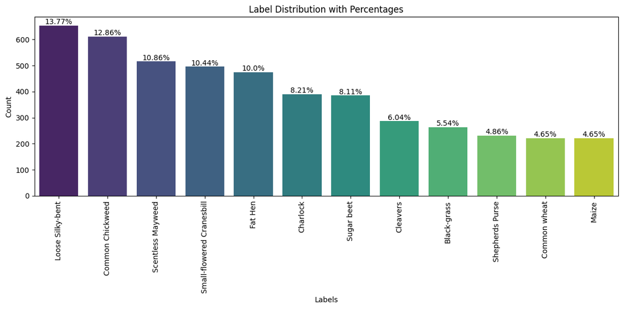

```python
display_label_count(labels)
```

**Observations**

- Looking at the images, domain knowledge and/or expertise are needed to classify them into proper categories, even for humans.
- The dataset apparently has an imbalanced distribution of labels.
- The most common label is `Loose Silky-bent` (13.77%), followed closely by `Common Chickweed` (12.86%).
- The least represented labels are `Maize` (4.65%), `Common Wheat` (4.65%), and `Shepherd's Purse` (4.86%).
- The class imbalance could bias the model toward the majority classes.
- Applying techniques like using class_weight or oversampling, undersampling, or data augmentation should be a good idea.

**Decision**

- I decided to Use the **class weights** approach during training, considering the below points
- No Data Duplication is needed
- Simpler, It integrates seamlessly into the `fit()` method
- Class weights dynamically adjust the importance of each class during training, which helps the model learn balanced features without manipulating the data.

## Data Pre-Processing

### Convert the BGR images to RGB images.

- As OpenCV Reads Images in BGR Format but TensorFlow/Keras expects images in RGB format, we need to convert BGR to RGB for consistency.

```python
# Image format conversion
for i in range(len(images)):
  image_bgr = images[i];
  # Converting images using cv2
  image_rgb = cv2.cvtColor(image_bgr, cv2.COLOR_BGR2RGB)
  images[i] = image_rgb;
```

### Resize the images

As the size of the images is large, it may be computationally expensive to train on these larger images; therefore, it is preferable to reduce the image size from 128 to 64.

- Advantages of Reducing the Image Size:
  - Smaller image sizes mean fewer input features, which significantly reduces the number of computations in convolutional and fully connected layers.
  - This is especially useful when training from scratch on limited hardware or for faster experimentation.
- Quicker Training:
  - With smaller input dimensions, the training process is faster while still capturing essential patterns (as long as the reduction doesn't lose critical information).
- Avoid Overfitting:
  - Smaller images can help prevent overfitting by limiting the model’s ability to memorize unnecessary details.

```python
images_resized = np.array([cv2.resize(img, (64, 64)) for img in images])
```

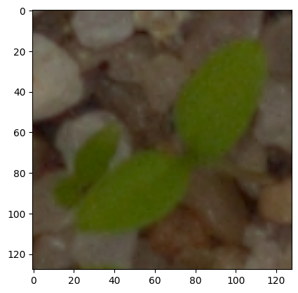

```python
random_number = random.randint(1, 4700)
plt.imshow(images[random_number]);
```

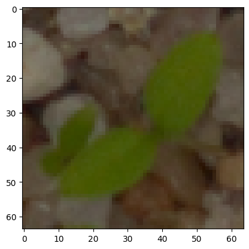

```python
plt.imshow(images_resized[random_number]);
```

**Observations**

To ensure that resizing to 64x64 does not result in a significant loss of information in the images, I displayed the same image above in both sizes. The observations show no significant distortions, though the resolution is affected. It is a good sign to proceed with the reduced image sizes.

### Data Preparation for Modeling

**Split the dataset**

```python
# Splitting data into Train (70%) and Temp (30%)
x_train, x_temp, y_train, y_temp = train_test_split(
    images_resized, labels, test_size=0.3, random_state=1, stratify=labels
)

# Splitting Temp into Validation (50% of Temp -> 15% overall) and Test (50% of Temp -> 15% overall)
x_val, x_test, y_val, y_test = train_test_split(
    x_temp, y_temp, test_size=0.5, random_state=1, stratify=y_temp
)

# Printing the shapes
print(f"Training Set: X={x_train.shape}, Y={y_train.shape}")
print(f"Validation Set: X={x_val.shape}, Y={y_val.shape}")
print(f"Test Set: X={x_test.shape}, Y={y_test.shape}")
```

```
Training Set: X=(3325, 64, 64, 3), Y=(3325, 1)
Validation Set: X=(712, 64, 64, 3), Y=(712, 1)
Test Set: X=(713, 64, 64, 3), Y=(713, 1)
```

### Encode the target labels

```python
# Initializing
label_binarizer = LabelBinarizer()

# Fit and transform
y_encoded = label_binarizer.fit_transform(labels['Label'])

# Verifying the shape
print("Encoded Labels Shape:", y_encoded.shape)
print("Sample Encoded Labels:\n", y_encoded[:5])

# Splitting data again after encoding if needed
y_train_encoded = label_binarizer.transform(y_train)
y_val_encoded = label_binarizer.transform(y_val)
y_test_encoded = label_binarizer.transform(y_test)
```

```
Encoded Labels Shape: (4750, 12)
Sample Encoded Labels:
 [[0 0 0 0 0 0 0 0 0 0 1 0]
 [0 0 0 0 0 0 0 0 0 0 1 0]
 [0 0 0 0 0 0 0 0 0 0 1 0]
 [0 0 0 0 0 0 0 0 0 0 1 0]
 [0 0 0 0 0 0 0 0 0 0 1 0]]
```

### Data Normalization

```python
# Converting the image data to float and normalize pixel values
x_train_normalized = x_train.astype('float32') / 255.0
x_val_normalized = x_val.astype('float32') / 255.0
x_test_normalized = x_test.astype('float32') / 255.0

# Verifying normalization by checking min and max values
print(f"Training data range: {x_train_normalized.min()} to {x_train_normalized.max()}")
print(f"Validation data range: {x_val_normalized.min()} to {x_val_normalized.max()}")
print(f"Test data range: {x_test_normalized.min()} to {x_test_normalized.max()}")
```

```
Training data range: 0.0 to 1.0
Validation data range: 0.0 to 1.0
Test data range: 0.0 to 1.0
```

## Model Building

### Utility functions - Common Codes and Model Evaluation functions

```python
# COOMON-CODE --> For Calculating Class Weights
y_train_labels = np.argmax(y_train_encoded, axis=1)  # y_train_encoded is one-hot encoding
# Extract unique class labels
class_labels = np.unique(y_train_labels)
class_weights = compute_class_weight('balanced', classes=class_labels, y=y_train_labels)
class_weights_dict = {i: weight for i, weight in enumerate(class_weights)}
print("Computed Class Weights:", class_weights_dict)
```

```
Computed Class Weights: {0: 1.5058876811594204, 1: 1.014957264957265, 2: 1.378524046434494, 3: 0.6473909657320872, 4: 1.7876344086021505, 5: 0.8345883534136547, 6: 0.6049854439592431, 7: 1.7876344086021505, 8: 0.7675438596491229, 9: 1.7103909465020577, 10: 0.7985110470701249, 11: 1.0300495662949194}
```

```python
# Function for setting seed for reproducibility & clearing session
def reset_environment(seed=1):
  backend.clear_session()
  np.random.seed(seed)
  random.seed(seed)
  tf.random.set_seed(seed)
  tf.random.set_seed(seed)
  tf.keras.utils.set_random_seed(seed)
  # tf.config.experimental.enable_op_determinism() <-- this does not work when using GPU in Google CoLab
```

```python
# Display loss plot for provided training history
def plot_loss(his):
  plt.plot(his.history['loss'])
  plt.plot(his.history['val_loss'])
  plt.title('Model Loss')
  plt.ylabel('Loss')
  plt.xlabel('Epoch')
  plt.legend(['Train', 'Validation'], loc='upper left')
  plt.show()

# Display accuracy plot for provided training history
def plot_accuracy(his):
  plt.plot(his.history['accuracy'])
  plt.plot(his.history['val_accuracy'])
  plt.title('Model Accuracy')
  plt.ylabel('Accuracy')
  plt.xlabel('Epoch')
  plt.legend(['Train', 'Validation'], loc='upper left')
  plt.show()
```

```python
# Function to display multi-class classification confusion matrix
def plot_confusion_matrix_and_report(model, x, y):
  y_pred = model.predict(x)
  # Calculate confusion matrix
  # Obtaining the categorical values
  y_pred_arg = np.argmax(y_pred, axis=1)
  y_arg = np.argmax(y, axis=1)

  # Plotting the Confusion Matrix
  cm = tf.math.confusion_matrix(y_arg, y_pred_arg)
  f, ax = plt.subplots(figsize=(12, 12))
  sns.heatmap(
      cm,
      annot=True,
      linewidths=.4,
      fmt="d",
      square=True,
      ax=ax
  )
  # Setting the labels
  ax.set_xlabel('Predicted labels');ax.set_ylabel('True labels');
  ax.set_title('Confusion Matrix');
  ax.xaxis.set_ticklabels(list(label_binarizer.classes_),rotation=40)
  ax.yaxis.set_ticklabels(list(label_binarizer.classes_),rotation=20)
  plt.show()
  cr = classification_report(y_arg, y_pred_arg)
  print(cr)
```

### Initial Model - first iteration

```python
# Building the model
model1 = Sequential([
    # First Conv2D layer
    Conv2D(filters=32, kernel_size=(3, 3), activation='relu', padding='same', input_shape=(64, 64, 3)),

    # Second Conv2D layer
    Conv2D(filters=64, kernel_size=(3, 3), activation='relu', padding='same'),

    # First MaxPooling layer
    MaxPooling2D(pool_size=(2, 2)),

    # Third Conv2D layer
    Conv2D(filters=128, kernel_size=(3, 3), activation='relu', padding='same'),

    # Second MaxPooling layer
    MaxPooling2D(pool_size=(2, 2)),

    # Flatten the output
    Flatten(),

    # First Dense layer with 16 neurons
    Dense(16, activation='relu'),

    # Output layer with 12 neurons for 12 classes
    Dense(12, activation='softmax')
])

# Compile the model
model1.compile(optimizer=Adam(),
               loss='categorical_crossentropy',
               metrics=['accuracy'])

# Print the model summary
model1.summary()
```

```
Model: "sequential"
```

```
┏━━━━━━━━━━━━━━━━━━━━━━━━━━━━━━━━━━━━━━┳━━━━━━━━━━━━━━━━━━━━━━━━━━━━━┳━━━━━━━━━━━━━━━━━┓
┃ Layer (type)                         ┃ Output Shape                ┃         Param # ┃
┡━━━━━━━━━━━━━━━━━━━━━━━━━━━━━━━━━━━━━━╇━━━━━━━━━━━━━━━━━━━━━━━━━━━━━╇━━━━━━━━━━━━━━━━━┩
│ conv2d (Conv2D)                      │ (None, 64, 64, 32)          │             896 │
├──────────────────────────────────────┼─────────────────────────────┼─────────────────┤
│ conv2d_1 (Conv2D)                    │ (None, 64, 64, 64)          │          18,496 │
├──────────────────────────────────────┼─────────────────────────────┼─────────────────┤
│ max_pooling2d (MaxPooling2D)         │ (None, 32, 32, 64)          │               0 │
├──────────────────────────────────────┼─────────────────────────────┼─────────────────┤
│ conv2d_2 (Conv2D)                    │ (None, 32, 32, 128)         │          73,856 │
├──────────────────────────────────────┼─────────────────────────────┼─────────────────┤
│ max_pooling2d_1 (MaxPooling2D)       │ (None, 16, 16, 128)         │               0 │
├──────────────────────────────────────┼─────────────────────────────┼─────────────────┤
│ flatten (Flatten)                    │ (None, 32768)               │               0 │
├──────────────────────────────────────┼─────────────────────────────┼─────────────────┤
│ dense (Dense)                        │ (None, 16)                  │         524,304 │
├──────────────────────────────────────┼─────────────────────────────┼─────────────────┤
│ dense_1 (Dense)                      │ (None, 12)                  │             204 │
└──────────────────────────────────────┴─────────────────────────────┴─────────────────┘
```

```
 Total params: 617,756 (2.36 MB)
```

```
 Trainable params: 617,756 (2.36 MB)
```

```
 Non-trainable params: 0 (0.00 B)
```

**Fitting the model on the train data**

```python
# Resetting the environment default seed=1
reset_environment()

# Fit the model
history1 = model1.fit(
            x_train_normalized,
            y_train_encoded,
            epochs=50,
            validation_data=(x_val_normalized,y_val_encoded),
            batch_size=32,
            class_weight=class_weights_dict,
            verbose=2
)
```

```
104/104 - 9s - 89ms/step - accuracy: 0.0586 - loss: 2.4879 - val_accuracy: 0.1081 - val_loss: 2.4846
104/104 - 4s - 35ms/step - accuracy: 0.1684 - loss: 2.3858 - val_accuracy: 0.2191 - val_loss: 2.2268
104/104 - 2s - 24ms/step - accuracy: 0.1808 - loss: 2.1848 - val_accuracy: 0.1910 - val_loss: 2.0911
104/104 - 1s - 12ms/step - accuracy: 0.2033 - loss: 2.0571 - val_accuracy: 0.2331 - val_loss: 1.9894
104/104 - 1s - 12ms/step - accuracy: 0.2376 - loss: 1.9568 - val_accuracy: 0.2669 - val_loss: 1.9061
104/104 - 1s - 13ms/step - accuracy: 0.2514 - loss: 1.8740 - val_accuracy: 0.2992 - val_loss: 1.8571
104/104 - 2s - 23ms/step - accuracy: 0.2863 - loss: 1.8027 - val_accuracy: 0.3343 - val_loss: 1.8168
104/104 - 1s - 12ms/step - accuracy: 0.3173 - loss: 1.7535 - val_accuracy: 0.3427 - val_loss: 1.8103
104/104 - 1s - 12ms/step - accuracy: 0.3245 - loss: 1.7212 - val_accuracy: 0.3539 - val_loss: 1.8127
104/104 - 1s - 12ms/step - accuracy: 0.3432 - loss: 1.6857 - val_accuracy: 0.3413 - val_loss: 1.8111
104/104 - 1s - 12ms/step - accuracy: 0.3573 - loss: 1.6636 - val_accuracy: 0.3539 - val_loss: 1.8432
104/104 - 1s - 12ms/step - accuracy: 0.3711 - loss: 1.6506 - val_accuracy: 0.3315 - val_loss: 1.8283
104/104 - 1s - 12ms/step - accuracy: 0.3696 - loss: 1.6189 - val_accuracy: 0.3441 - val_loss: 1.7755
104/104 - 1s - 12ms/step - accuracy: 0.3865 - loss: 1.5723 - val_accuracy: 0.3469 - val_loss: 1.7939
104/104 - 1s - 13ms/step - accuracy: 0.4024 - loss: 1.5228 - val_accuracy: 0.3553 - val_loss: 1.8043
104/104 - 1s - 13ms/step - accuracy: 0.4084 - loss: 1.5085 - val_accuracy: 0.3497 - val_loss: 1.7758
104/104 - 1s - 13ms/step - accuracy: 0.4102 - loss: 1.4640 - val_accuracy: 0.3301 - val_loss: 1.8260
104/104 - 2s - 24ms/step - accuracy: 0.4274 - loss: 1.4278 - val_accuracy: 0.3343 - val_loss: 1.8257
104/104 - 1s - 12ms/step - accuracy: 0.4241 - loss: 1.4066 - val_accuracy: 0.3469 - val_loss: 1.8382
104/104 - 1s - 13ms/step - accuracy: 0.4370 - loss: 1.3758 - val_accuracy: 0.3525 - val_loss: 1.9152
104/104 - 2s - 24ms/step - accuracy: 0.4349 - loss: 1.3601 - val_accuracy: 0.3301 - val_loss: 1.9733
104/104 - 1s - 13ms/step - accuracy: 0.4358 - loss: 1.3393 - val_accuracy: 0.3315 - val_loss: 1.9477
104/104 - 3s - 25ms/step - accuracy: 0.4361 - loss: 1.3295 - val_accuracy: 0.3399 - val_loss: 1.9014
104/104 - 1s - 13ms/step - accuracy: 0.4355 - loss: 1.3604 - val_accuracy: 0.3497 - val_loss: 1.8440
104/104 - 1s - 13ms/step - accuracy: 0.4740 - loss: 1.2472 - val_accuracy: 0.3553 - val_loss: 1.9416
104/104 - 1s - 12ms/step - accuracy: 0.4953 - loss: 1.1875 - val_accuracy: 0.3539 - val_loss: 2.0510
104/104 - 1s - 13ms/step - accuracy: 0.5089 - loss: 1.1347 - val_accuracy: 0.3441 - val_loss: 2.1178
104/104 - 2s - 24ms/step - accuracy: 0.5191 - loss: 1.0999 - val_accuracy: 0.3469 - val_loss: 2.1812
104/104 - 1s - 12ms/step - accuracy: 0.5338 - loss: 1.0761 - val_accuracy: 0.3525 - val_loss: 2.2380
104/104 - 1s - 12ms/step - accuracy: 0.5374 - loss: 1.0744 - val_accuracy: 0.3553 - val_loss: 2.2195
104/104 - 3s - 24ms/step - accuracy: 0.5230 - loss: 1.0672 - val_accuracy: 0.3680 - val_loss: 2.3535
104/104 - 3s - 25ms/step - accuracy: 0.5293 - loss: 1.0764 - val_accuracy: 0.3399 - val_loss: 2.4034
104/104 - 2s - 24ms/step - accuracy: 0.5377 - loss: 1.0444 - val_accuracy: 0.3652 - val_loss: 2.1508
104/104 - 1s - 12ms/step - accuracy: 0.5429 - loss: 1.0224 - val_accuracy: 0.3455 - val_loss: 2.1989
104/104 - 2s - 24ms/step - accuracy: 0.5765 - loss: 0.9808 - val_accuracy: 0.3483 - val_loss: 2.3913
104/104 - 1s - 13ms/step - accuracy: 0.5774 - loss: 0.9716 - val_accuracy: 0.3652 - val_loss: 2.4277
104/104 - 1s - 12ms/step - accuracy: 0.5829 - loss: 0.9731 - val_accuracy: 0.3722 - val_loss: 2.4276
104/104 - 1s - 12ms/step - accuracy: 0.5699 - loss: 0.9800 - val_accuracy: 0.3581 - val_loss: 2.4464
104/104 - 1s - 13ms/step - accuracy: 0.5771 - loss: 0.9834 - val_accuracy: 0.3343 - val_loss: 2.5602
104/104 - 2s - 24ms/step - accuracy: 0.5994 - loss: 0.9377 - val_accuracy: 0.3427 - val_loss: 2.7252
104/104 - 1s - 12ms/step - accuracy: 0.5997 - loss: 0.9203 - val_accuracy: 0.3497 - val_loss: 2.5780
104/104 - 1s - 12ms/step - accuracy: 0.6298 - loss: 0.8677 - val_accuracy: 0.3455 - val_loss: 2.8309
104/104 - 1s - 12ms/step - accuracy: 0.6523 - loss: 0.8475 - val_accuracy: 0.3553 - val_loss: 2.9278
104/104 - 1s - 12ms/step - accuracy: 0.6415 - loss: 0.8627 - val_accuracy: 0.3722 - val_loss: 2.8745
104/104 - 1s - 12ms/step - accuracy: 0.6235 - loss: 0.9178 - val_accuracy: 0.3764 - val_loss: 2.9087
104/104 - 1s - 12ms/step - accuracy: 0.6042 - loss: 0.9236 - val_accuracy: 0.3553 - val_loss: 2.8286
104/104 - 1s - 12ms/step - accuracy: 0.6325 - loss: 0.8793 - val_accuracy: 0.3848 - val_loss: 2.6239
104/104 - 1s - 12ms/step - accuracy: 0.6493 - loss: 0.8115 - val_accuracy: 0.3497 - val_loss: 2.9943
104/104 - 3s - 25ms/step - accuracy: 0.6725 - loss: 0.7891 - val_accuracy: 0.3750 - val_loss: 2.9498
104/104 - 2s - 23ms/step - accuracy: 0.6761 - loss: 0.7900 - val_accuracy: 0.3778 - val_loss: 2.8940
```

**Model Evaluation**

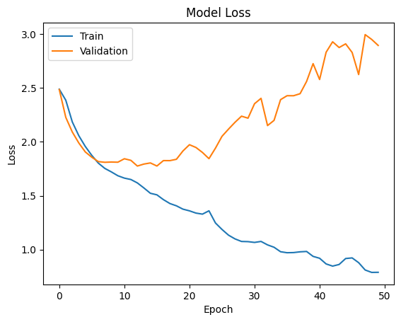

```python
plot_loss(history1)
```

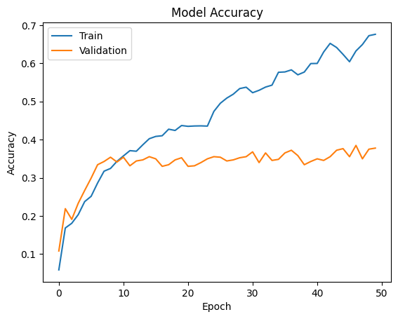

```python
plot_accuracy(history1)
```

```
23/23 ━━━━━━━━━━━━━━━━━━━━ 0s 11ms/step
```

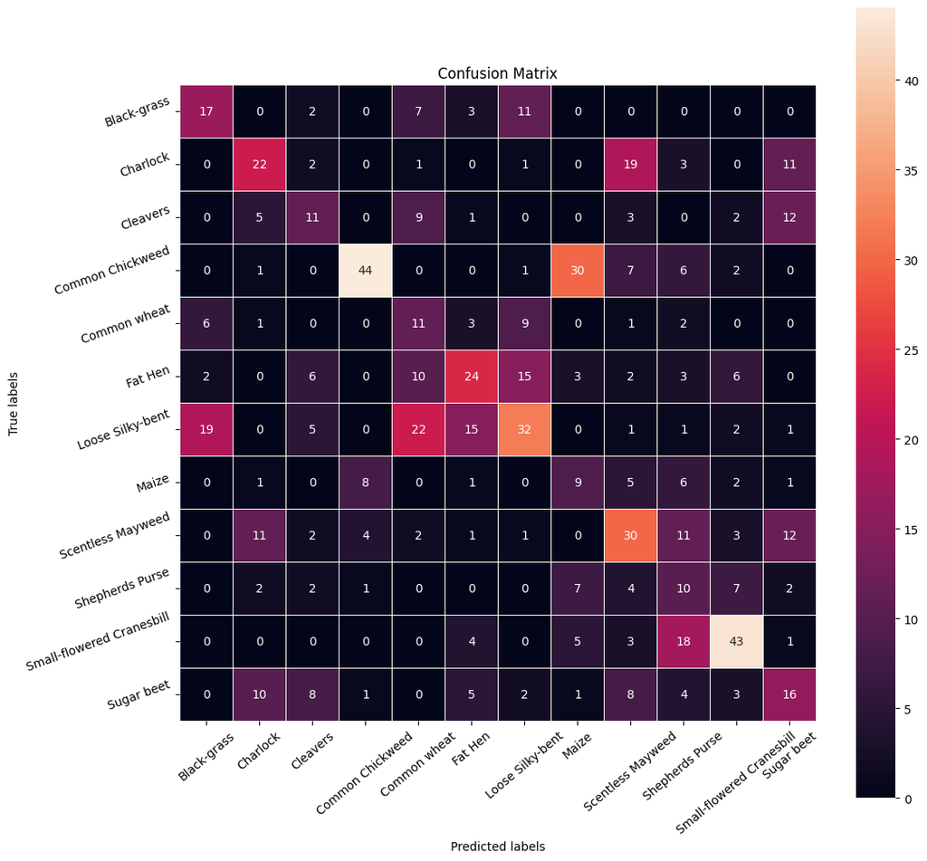

```
              precision    recall  f1-score   support

           0       0.39      0.42      0.40        40
           1       0.42      0.37      0.39        59
           2       0.29      0.26      0.27        43
           3       0.76      0.48      0.59        91
           4       0.18      0.33      0.23        33
           5       0.42      0.34      0.38        71
           6       0.44      0.33      0.38        98
           7       0.16      0.27      0.20        33
           8       0.36      0.39      0.38        77
           9       0.16      0.29      0.20        35
          10       0.61      0.58      0.60        74
          11       0.29      0.28      0.28        58

    accuracy                           0.38       712
   macro avg       0.37      0.36      0.36       712
weighted avg       0.42      0.38      0.39       712
```

```python
plot_confusion_matrix_and_report(model1, x_val_normalized, y_val_encoded)
```

#### **Observations**

**Loss and Accuracy Plots**:

- The training loss consistently decreases, and training accuracy steadily increases, indicating the model is learning the training data well. Training accuracy reaches **~70%** by the end of 50 epochs.
- Validation loss decreases initially but starts to oscillate and increase after ~25 epochs, indicating overfitting. Validation accuracy plateaus at **~38%**, showing poor generalization to the validation set.

**Confusion Matrix**:

**Classification Report**:

**Issues with this Model:**

1. **Overfitting**: Training accuracy is significantly higher than validation accuracy, and validation loss increases over epochs. The model is overfitting to the training data.
2. **Class Imbalance**: The model struggles to handle class imbalance effectively, despite using `class_weight`. This is evident in the poor recall and precision for minority classes.
3. **Model Complexity**: The current architecture may not have sufficient capacity to capture complex features in the dataset. A deeper model with more layers or filters may help.
4. **No Regularization**: No techniques like Batch Normalization or Dropout are applied, leading to overfitting.

## Model Performance Improvement

### Second Iteration

**Improvement Opinions**

- Add BatchNormalization after convolutional layers to stabilize learning.
- Add more convolutional layers or increase the number of filters in existing layers to allow the model to capture more complex patterns
- Use a learning rate of 1e-4 instead of the default 1e-3 to allow finer adjustments to weights.

```python
# Building the second model
model2 = Sequential([
    # First Conv2D layer
    Conv2D(filters=32, kernel_size=(3, 3), activation='relu', padding='same', input_shape=(64, 64, 3)),

    # Second Conv2D layer
    Conv2D(filters=64, kernel_size=(3, 3), activation='relu', padding='same'),

    # First MaxPooling layer
    MaxPooling2D(pool_size=(2, 2)),

    # Third Conv2D layer <-- Added New
    Conv2D(filters=64, kernel_size=(3, 3), activation='relu', padding='same'),

    # Fourth Conv2D layer
    Conv2D(filters=128, kernel_size=(3, 3), activation='relu', padding='same'),

    # Second MaxPooling layer
    MaxPooling2D(pool_size=(2, 2)),

    # BatchNormalization <-- Added New
    BatchNormalization(),

    # Flatten the output
    Flatten(),

    # First Dense layer with 16 neurons
    Dense(16, activation='relu'),

    # Output layer with 12 neurons for 12 classes
    Dense(12, activation='softmax')
])

# Compile the model
model2.compile(optimizer=Adam(learning_rate=1e-4),# Reduced learning_rate=0.0005 <-- Added new
               loss='categorical_crossentropy',
               metrics=['accuracy'])

# Print the model summary
model2.summary()
```

```
Model: "sequential_1"
```

```
┏━━━━━━━━━━━━━━━━━━━━━━━━━━━━━━━━━━━━━━┳━━━━━━━━━━━━━━━━━━━━━━━━━━━━━┳━━━━━━━━━━━━━━━━━┓
┃ Layer (type)                         ┃ Output Shape                ┃         Param # ┃
┡━━━━━━━━━━━━━━━━━━━━━━━━━━━━━━━━━━━━━━╇━━━━━━━━━━━━━━━━━━━━━━━━━━━━━╇━━━━━━━━━━━━━━━━━┩
│ conv2d_4 (Conv2D)                    │ (None, 64, 64, 32)          │             896 │
├──────────────────────────────────────┼─────────────────────────────┼─────────────────┤
│ conv2d_5 (Conv2D)                    │ (None, 64, 64, 64)          │          18,496 │
├──────────────────────────────────────┼─────────────────────────────┼─────────────────┤
│ max_pooling2d_2 (MaxPooling2D)       │ (None, 32, 32, 64)          │               0 │
├──────────────────────────────────────┼─────────────────────────────┼─────────────────┤
│ conv2d_6 (Conv2D)                    │ (None, 32, 32, 64)          │          36,928 │
├──────────────────────────────────────┼─────────────────────────────┼─────────────────┤
│ conv2d_7 (Conv2D)                    │ (None, 32, 32, 128)         │          73,856 │
├──────────────────────────────────────┼─────────────────────────────┼─────────────────┤
│ max_pooling2d_3 (MaxPooling2D)       │ (None, 16, 16, 128)         │               0 │
├──────────────────────────────────────┼─────────────────────────────┼─────────────────┤
│ batch_normalization_1                │ (None, 16, 16, 128)         │             512 │
│ (BatchNormalization)                 │                             │                 │
├──────────────────────────────────────┼─────────────────────────────┼─────────────────┤
│ flatten_1 (Flatten)                  │ (None, 32768)               │               0 │
├──────────────────────────────────────┼─────────────────────────────┼─────────────────┤
│ dense_2 (Dense)                      │ (None, 16)                  │         524,304 │
├──────────────────────────────────────┼─────────────────────────────┼─────────────────┤
│ dense_3 (Dense)                      │ (None, 12)                  │             204 │
└──────────────────────────────────────┴─────────────────────────────┴─────────────────┘
```

```
 Total params: 655,196 (2.50 MB)
```

```
 Trainable params: 654,940 (2.50 MB)
```

```
 Non-trainable params: 256 (1.00 KB)
```

```python
# Resetting the environment default seed=1
reset_environment()

# Fit the model
history2 = model2.fit(
            x_train_normalized,
            y_train_encoded,
            epochs=50,
            validation_data=(x_val_normalized,y_val_encoded),
            batch_size=32,
            class_weight=class_weights_dict,
            verbose=2
)
```

```
104/104 - 10s - 97ms/step - accuracy: 0.2162 - loss: 2.2047 - val_accuracy: 0.1854 - val_loss: 2.4180
104/104 - 2s - 15ms/step - accuracy: 0.3874 - loss: 1.6098 - val_accuracy: 0.2992 - val_loss: 2.2801
104/104 - 2s - 15ms/step - accuracy: 0.5531 - loss: 1.2259 - val_accuracy: 0.4733 - val_loss: 2.0092
104/104 - 2s - 15ms/step - accuracy: 0.6788 - loss: 0.9448 - val_accuracy: 0.5506 - val_loss: 1.6380
104/104 - 2s - 24ms/step - accuracy: 0.7603 - loss: 0.7325 - val_accuracy: 0.5772 - val_loss: 1.2894
104/104 - 3s - 24ms/step - accuracy: 0.8352 - loss: 0.5630 - val_accuracy: 0.6081 - val_loss: 1.1665
104/104 - 2s - 24ms/step - accuracy: 0.8722 - loss: 0.4467 - val_accuracy: 0.6362 - val_loss: 1.1952
104/104 - 1s - 14ms/step - accuracy: 0.9023 - loss: 0.3515 - val_accuracy: 0.5913 - val_loss: 1.4839
104/104 - 2s - 15ms/step - accuracy: 0.9209 - loss: 0.2861 - val_accuracy: 0.5197 - val_loss: 1.9568
104/104 - 3s - 25ms/step - accuracy: 0.9426 - loss: 0.2348 - val_accuracy: 0.5815 - val_loss: 1.6466
104/104 - 2s - 15ms/step - accuracy: 0.9570 - loss: 0.1802 - val_accuracy: 0.5295 - val_loss: 2.0402
104/104 - 2s - 24ms/step - accuracy: 0.9753 - loss: 0.1371 - val_accuracy: 0.5492 - val_loss: 1.8564
104/104 - 3s - 25ms/step - accuracy: 0.9868 - loss: 0.1007 - val_accuracy: 0.5899 - val_loss: 1.5816
104/104 - 3s - 24ms/step - accuracy: 0.9931 - loss: 0.0711 - val_accuracy: 0.6657 - val_loss: 1.3870
104/104 - 2s - 15ms/step - accuracy: 0.9964 - loss: 0.0544 - val_accuracy: 0.6770 - val_loss: 1.2908
104/104 - 3s - 25ms/step - accuracy: 0.9982 - loss: 0.0427 - val_accuracy: 0.6910 - val_loss: 1.3511
104/104 - 2s - 24ms/step - accuracy: 0.9982 - loss: 0.0342 - val_accuracy: 0.6713 - val_loss: 1.3461
104/104 - 1s - 14ms/step - accuracy: 0.9991 - loss: 0.0261 - val_accuracy: 0.6840 - val_loss: 1.3300
104/104 - 3s - 25ms/step - accuracy: 0.9991 - loss: 0.0202 - val_accuracy: 0.6882 - val_loss: 1.3796
104/104 - 2s - 24ms/step - accuracy: 0.9997 - loss: 0.0167 - val_accuracy: 0.6826 - val_loss: 1.3975
104/104 - 2s - 15ms/step - accuracy: 0.9997 - loss: 0.0140 - val_accuracy: 0.6784 - val_loss: 1.4246
104/104 - 2s - 15ms/step - accuracy: 0.9997 - loss: 0.0119 - val_accuracy: 0.6784 - val_loss: 1.4164
104/104 - 2s - 24ms/step - accuracy: 0.9997 - loss: 0.0107 - val_accuracy: 0.6798 - val_loss: 1.4395
104/104 - 3s - 25ms/step - accuracy: 0.9997 - loss: 0.0092 - val_accuracy: 0.6812 - val_loss: 1.4460
104/104 - 2s - 15ms/step - accuracy: 0.9997 - loss: 0.0081 - val_accuracy: 0.6826 - val_loss: 1.4377
104/104 - 3s - 24ms/step - accuracy: 0.9997 - loss: 0.0072 - val_accuracy: 0.6868 - val_loss: 1.4278
104/104 - 3s - 25ms/step - accuracy: 0.9997 - loss: 0.0065 - val_accuracy: 0.6910 - val_loss: 1.4128
104/104 - 2s - 15ms/step - accuracy: 0.9997 - loss: 0.0059 - val_accuracy: 0.6966 - val_loss: 1.4098
104/104 - 2s - 16ms/step - accuracy: 0.9997 - loss: 0.0056 - val_accuracy: 0.7008 - val_loss: 1.4114
104/104 - 2s - 23ms/step - accuracy: 0.9997 - loss: 0.0049 - val_accuracy: 0.7051 - val_loss: 1.4172
104/104 - 3s - 24ms/step - accuracy: 0.9997 - loss: 0.0044 - val_accuracy: 0.7051 - val_loss: 1.4150
104/104 - 3s - 24ms/step - accuracy: 0.9997 - loss: 0.0040 - val_accuracy: 0.7135 - val_loss: 1.4217
104/104 - 2s - 15ms/step - accuracy: 0.9997 - loss: 0.0037 - val_accuracy: 0.7205 - val_loss: 1.4312
104/104 - 3s - 25ms/step - accuracy: 0.9997 - loss: 0.0034 - val_accuracy: 0.7191 - val_loss: 1.4418
104/104 - 2s - 15ms/step - accuracy: 0.9997 - loss: 0.0032 - val_accuracy: 0.7219 - val_loss: 1.4453
104/104 - 2s - 15ms/step - accuracy: 0.9997 - loss: 0.0029 - val_accuracy: 0.7149 - val_loss: 1.4582
104/104 - 2s - 15ms/step - accuracy: 0.9997 - loss: 0.0027 - val_accuracy: 0.7135 - val_loss: 1.4672
104/104 - 3s - 24ms/step - accuracy: 0.9976 - loss: 0.0091 - val_accuracy: 0.4944 - val_loss: 3.7317
104/104 - 2s - 15ms/step - accuracy: 0.9347 - loss: 0.2042 - val_accuracy: 0.5758 - val_loss: 2.0891
104/104 - 2s - 24ms/step - accuracy: 0.9555 - loss: 0.1440 - val_accuracy: 0.5028 - val_loss: 3.1505
104/104 - 2s - 15ms/step - accuracy: 0.9904 - loss: 0.0384 - val_accuracy: 0.6461 - val_loss: 1.8803
104/104 - 2s - 15ms/step - accuracy: 0.9997 - loss: 0.0077 - val_accuracy: 0.6938 - val_loss: 1.7021
104/104 - 2s - 15ms/step - accuracy: 0.9997 - loss: 0.0042 - val_accuracy: 0.6994 - val_loss: 1.6878
104/104 - 1s - 14ms/step - accuracy: 0.9997 - loss: 0.0033 - val_accuracy: 0.7037 - val_loss: 1.7050
104/104 - 1s - 14ms/step - accuracy: 0.9997 - loss: 0.0028 - val_accuracy: 0.7022 - val_loss: 1.7121
104/104 - 1s - 14ms/step - accuracy: 0.9997 - loss: 0.0026 - val_accuracy: 0.6994 - val_loss: 1.7112
104/104 - 3s - 25ms/step - accuracy: 0.9997 - loss: 0.0023 - val_accuracy: 0.7022 - val_loss: 1.7150
104/104 - 2s - 24ms/step - accuracy: 0.9997 - loss: 0.0021 - val_accuracy: 0.6994 - val_loss: 1.7178
104/104 - 3s - 25ms/step - accuracy: 0.9997 - loss: 0.0020 - val_accuracy: 0.7008 - val_loss: 1.7151
104/104 - 2s - 15ms/step - accuracy: 0.9997 - loss: 0.0019 - val_accuracy: 0.6952 - val_loss: 1.7200
```

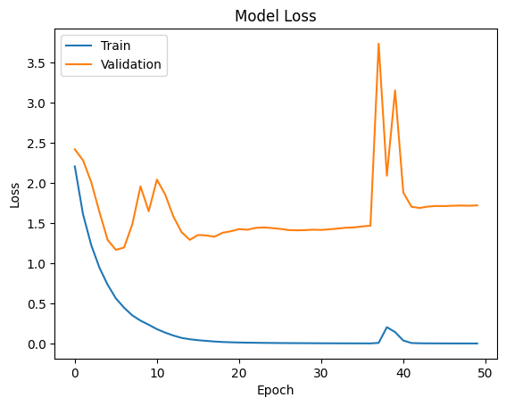

```python
plot_loss(history2)
```

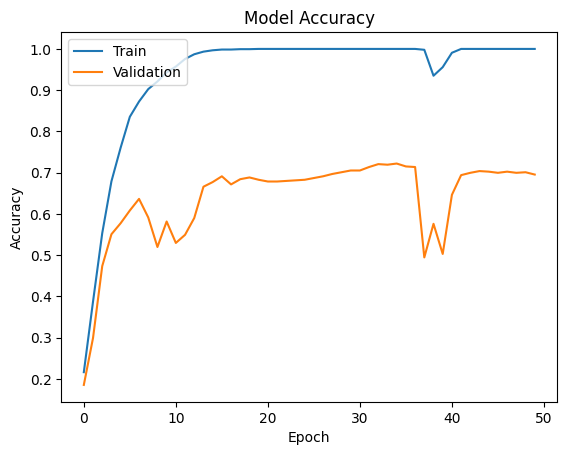

```python
plot_accuracy(history2)
```

```
23/23 ━━━━━━━━━━━━━━━━━━━━ 1s 17ms/step
```

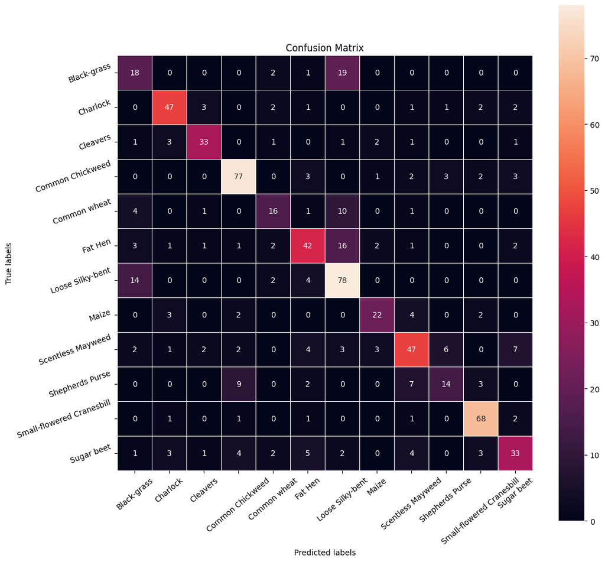

```
              precision    recall  f1-score   support

           0       0.42      0.45      0.43        40
           1       0.80      0.80      0.80        59
           2       0.80      0.77      0.79        43
           3       0.80      0.85      0.82        91
           4       0.59      0.48      0.53        33
           5       0.66      0.59      0.62        71
           6       0.60      0.80      0.69        98
           7       0.73      0.67      0.70        33
           8       0.68      0.61      0.64        77
           9       0.58      0.40      0.47        35
          10       0.85      0.92      0.88        74
          11       0.66      0.57      0.61        58

    accuracy                           0.70       712
   macro avg       0.68      0.66      0.67       712
weighted avg       0.70      0.70      0.69       712
```

```python
plot_confusion_matrix_and_report(model2, x_val_normalized, y_val_encoded)
```

#### **Observations**

**Loss and Accuracy Plots**:

- Training loss decreases consistently to near **0.0**, and training accuracy reaches **~1.0**. This shows that the model is fitting the training data very well, indicating a potential risk of overfitting.
- Validation loss decreases initially but fluctuates and rises after around 25 epochs. Validation accuracy stabilizes at **~70%**, which is a significant improvement compared to the first model.

**Confusion Matrix**:

- The confusion matrix shows a **better spread of predictions across classes** compared to the first model.
- Classes such as `Loose Silky-bent`, `Common Chickweed`, and `Small-flowered Cranesbill` are predicted more accurately. Misclassifications are still present but significantly reduced.
- Some confusions persist, for example:
- `Loose Silky-bent` is occasionally misclassified as `Black-grass`.
- `Scentless Mayweed` is confused with `Shepherds Purse`.

**Classification Report**:

**Improvements Made:**

1. **Model Complexity**: Shifting to fourth `Conv2D` layer by adding extra `Conv2D` with **64 filters** improved the model's feature extraction capability.
2. **Batch Normalization**: The addition of `BatchNormalization` stabilized training and helped generalization, contributing to better validation performance.
3. **Learning Rate Adjustment**: Lowering the learning rate to `1e-4` allowed the model to converge more effectively, resulting in improved validation accuracy.

**Still exists issues:**

1. **Overfitting**: Training accuracy is significantly higher than validation accuracy, and validation loss fluctuates and increases after ~25 epochs. This indicates overfitting, despite the improvements.
2. **Misclassifications**: Certain confusions persist, especially for underrepresented or visually similar classes.
3. **Class Imbalance**: Class imbalance is still a challenge, as seen in the relatively lower performance for minority classes like `Maize` and `Shepherds Purse`.

### Third Iteration

**Improvement Options**

- Data Augmentation - Apply ImageDataGenerator to artificially increase the variability of training data and improve generalization.
- Add another dense layer before the output layer or increase neurons in the existing dense layer.
- Add Dropout layers after dense layers and convolutional layers to reduce overfitting.

```python
# Creating & Fitting DataGenerator <-- Added new

augmented_datagen = ImageDataGenerator(
    rotation_range=20,
    width_shift_range=0.2,
    height_shift_range=0.2,
    horizontal_flip=True
)
augmented_datagen.fit(x_train_normalized)




# Building the third model
model3 = Sequential([
    # First Conv2D layer
    Conv2D(filters=32, kernel_size=(3, 3), activation='relu', padding='same', input_shape=(64, 64, 3)),

    # Second Conv2D layer
    Conv2D(filters=64, kernel_size=(3, 3), activation='relu', padding='same'),

    # First MaxPooling layer
    MaxPooling2D(pool_size=(2, 2)),

    # Third Conv2D layer
    Conv2D(filters=64, kernel_size=(3, 3), activation='relu', padding='same'),

    # Fourth Conv2D layer
    Conv2D(filters=128, kernel_size=(3, 3), activation='relu', padding='same'),

    # Second MaxPooling layer
    MaxPooling2D(pool_size=(2, 2)),

    # First Dropout Layer<-- Added New
    Dropout(0.25),


    # BatchNormalization
    BatchNormalization(),

    # Flatten the output
    Flatten(),

    # First Dense layer with 16 neurons
    Dense(16, activation='relu'),

    # Second Dense layer with 32 neurons <-- Added New
    Dense(32, activation='relu'),

    # Second Dropout Layer<-- Added New
    Dropout(0.25),

    # Output layer with 12 neurons for 12 classes
    Dense(12, activation='softmax')
])

# Compile the model
model3.compile(optimizer=Adam(learning_rate=1e-4),# Reduced learning_rate=0.0005
               loss='categorical_crossentropy',
               metrics=['accuracy'])

# Print the model summary
model3.summary()
```

```
Model: "sequential_1"
```

```
┏━━━━━━━━━━━━━━━━━━━━━━━━━━━━━━━━━━━━━━┳━━━━━━━━━━━━━━━━━━━━━━━━━━━━━┳━━━━━━━━━━━━━━━━━┓
┃ Layer (type)                         ┃ Output Shape                ┃         Param # ┃
┡━━━━━━━━━━━━━━━━━━━━━━━━━━━━━━━━━━━━━━╇━━━━━━━━━━━━━━━━━━━━━━━━━━━━━╇━━━━━━━━━━━━━━━━━┩
│ conv2d_4 (Conv2D)                    │ (None, 64, 64, 32)          │             896 │
├──────────────────────────────────────┼─────────────────────────────┼─────────────────┤
│ conv2d_5 (Conv2D)                    │ (None, 64, 64, 64)          │          18,496 │
├──────────────────────────────────────┼─────────────────────────────┼─────────────────┤
│ max_pooling2d_2 (MaxPooling2D)       │ (None, 32, 32, 64)          │               0 │
├──────────────────────────────────────┼─────────────────────────────┼─────────────────┤
│ conv2d_6 (Conv2D)                    │ (None, 32, 32, 64)          │          36,928 │
├──────────────────────────────────────┼─────────────────────────────┼─────────────────┤
│ conv2d_7 (Conv2D)                    │ (None, 32, 32, 128)         │          73,856 │
├──────────────────────────────────────┼─────────────────────────────┼─────────────────┤
│ max_pooling2d_3 (MaxPooling2D)       │ (None, 16, 16, 128)         │               0 │
├──────────────────────────────────────┼─────────────────────────────┼─────────────────┤
│ dropout_2 (Dropout)                  │ (None, 16, 16, 128)         │               0 │
├──────────────────────────────────────┼─────────────────────────────┼─────────────────┤
│ batch_normalization_1                │ (None, 16, 16, 128)         │             512 │
│ (BatchNormalization)                 │                             │                 │
├──────────────────────────────────────┼─────────────────────────────┼─────────────────┤
│ flatten_1 (Flatten)                  │ (None, 32768)               │               0 │
├──────────────────────────────────────┼─────────────────────────────┼─────────────────┤
│ dense_3 (Dense)                      │ (None, 16)                  │         524,304 │
├──────────────────────────────────────┼─────────────────────────────┼─────────────────┤
│ dense_4 (Dense)                      │ (None, 32)                  │             544 │
├──────────────────────────────────────┼─────────────────────────────┼─────────────────┤
│ dropout_3 (Dropout)                  │ (None, 32)                  │               0 │
├──────────────────────────────────────┼─────────────────────────────┼─────────────────┤
│ dense_5 (Dense)                      │ (None, 12)                  │             396 │
└──────────────────────────────────────┴─────────────────────────────┴─────────────────┘
```

```
 Total params: 655,932 (2.50 MB)
```

```
 Trainable params: 655,676 (2.50 MB)
```

```
 Non-trainable params: 256 (1.00 KB)
```

```python
# Resetting the environment default seed=1
reset_environment()

# Fit the model
history3 = model3.fit(
          augmented_datagen.flow( # Data Augmentation <-- Added New
              x_train_normalized,
              y_train_encoded,
              batch_size=32),
          epochs=50,
          validation_data=(x_val_normalized,
                            y_val_encoded),
          class_weight=class_weights_dict,
          verbose=2)
```

```
104/104 - 25s - 238ms/step - accuracy: 0.0824 - loss: 2.4888 - val_accuracy: 0.0590 - val_loss: 2.4854
104/104 - 24s - 233ms/step - accuracy: 0.0896 - loss: 2.4392 - val_accuracy: 0.1742 - val_loss: 2.4669
104/104 - 4s - 38ms/step - accuracy: 0.1308 - loss: 2.3840 - val_accuracy: 0.1236 - val_loss: 2.4258
104/104 - 6s - 59ms/step - accuracy: 0.2066 - loss: 2.2591 - val_accuracy: 0.2177 - val_loss: 2.3125
104/104 - 5s - 45ms/step - accuracy: 0.2941 - loss: 2.1051 - val_accuracy: 0.2542 - val_loss: 2.0872
104/104 - 4s - 38ms/step - accuracy: 0.3398 - loss: 1.9675 - val_accuracy: 0.3975 - val_loss: 1.8269
104/104 - 4s - 42ms/step - accuracy: 0.3603 - loss: 1.8671 - val_accuracy: 0.4874 - val_loss: 1.6008
104/104 - 5s - 52ms/step - accuracy: 0.3765 - loss: 1.8125 - val_accuracy: 0.4747 - val_loss: 1.5606
104/104 - 10s - 91ms/step - accuracy: 0.4006 - loss: 1.7406 - val_accuracy: 0.4789 - val_loss: 1.3795
104/104 - 5s - 49ms/step - accuracy: 0.4256 - loss: 1.6812 - val_accuracy: 0.4944 - val_loss: 1.4736
104/104 - 10s - 98ms/step - accuracy: 0.4466 - loss: 1.6049 - val_accuracy: 0.5576 - val_loss: 1.2525
104/104 - 5s - 47ms/step - accuracy: 0.4550 - loss: 1.5417 - val_accuracy: 0.6250 - val_loss: 1.1483
104/104 - 4s - 38ms/step - accuracy: 0.4794 - loss: 1.4777 - val_accuracy: 0.4382 - val_loss: 1.5128
104/104 - 6s - 61ms/step - accuracy: 0.4803 - loss: 1.4814 - val_accuracy: 0.5787 - val_loss: 1.1904
104/104 - 4s - 41ms/step - accuracy: 0.4977 - loss: 1.4364 - val_accuracy: 0.6320 - val_loss: 1.0410
104/104 - 4s - 37ms/step - accuracy: 0.5071 - loss: 1.3926 - val_accuracy: 0.5744 - val_loss: 1.2002
104/104 - 5s - 45ms/step - accuracy: 0.5041 - loss: 1.3596 - val_accuracy: 0.6320 - val_loss: 1.0475
104/104 - 5s - 47ms/step - accuracy: 0.5275 - loss: 1.3164 - val_accuracy: 0.6138 - val_loss: 1.0857
104/104 - 5s - 45ms/step - accuracy: 0.5389 - loss: 1.3017 - val_accuracy: 0.6573 - val_loss: 0.9416
104/104 - 5s - 48ms/step - accuracy: 0.5576 - loss: 1.2704 - val_accuracy: 0.5885 - val_loss: 1.0916
104/104 - 4s - 43ms/step - accuracy: 0.5477 - loss: 1.2291 - val_accuracy: 0.6194 - val_loss: 1.0011
104/104 - 4s - 37ms/step - accuracy: 0.5768 - loss: 1.2007 - val_accuracy: 0.6840 - val_loss: 0.9379
104/104 - 8s - 80ms/step - accuracy: 0.5865 - loss: 1.1704 - val_accuracy: 0.6671 - val_loss: 0.9104
104/104 - 4s - 38ms/step - accuracy: 0.5874 - loss: 1.1610 - val_accuracy: 0.6812 - val_loss: 0.9318
104/104 - 4s - 39ms/step - accuracy: 0.6021 - loss: 1.1050 - val_accuracy: 0.6222 - val_loss: 1.0808
104/104 - 6s - 56ms/step - accuracy: 0.6150 - loss: 1.0763 - val_accuracy: 0.4916 - val_loss: 1.4650
104/104 - 4s - 37ms/step - accuracy: 0.6307 - loss: 1.0768 - val_accuracy: 0.7514 - val_loss: 0.7269
104/104 - 5s - 49ms/step - accuracy: 0.6406 - loss: 1.0228 - val_accuracy: 0.7739 - val_loss: 0.7146
104/104 - 7s - 63ms/step - accuracy: 0.6358 - loss: 1.0350 - val_accuracy: 0.6475 - val_loss: 1.0014
104/104 - 10s - 93ms/step - accuracy: 0.6481 - loss: 0.9739 - val_accuracy: 0.5983 - val_loss: 1.1749
104/104 - 5s - 47ms/step - accuracy: 0.6644 - loss: 0.9754 - val_accuracy: 0.7416 - val_loss: 0.6945
104/104 - 4s - 37ms/step - accuracy: 0.6647 - loss: 0.9579 - val_accuracy: 0.7008 - val_loss: 0.8546
104/104 - 4s - 40ms/step - accuracy: 0.6737 - loss: 0.9408 - val_accuracy: 0.6138 - val_loss: 1.0805
104/104 - 6s - 56ms/step - accuracy: 0.6938 - loss: 0.8978 - val_accuracy: 0.7205 - val_loss: 0.7687
104/104 - 4s - 38ms/step - accuracy: 0.6980 - loss: 0.8925 - val_accuracy: 0.7739 - val_loss: 0.6521
104/104 - 4s - 42ms/step - accuracy: 0.7002 - loss: 0.8748 - val_accuracy: 0.7640 - val_loss: 0.6673
104/104 - 6s - 54ms/step - accuracy: 0.7128 - loss: 0.8401 - val_accuracy: 0.7781 - val_loss: 0.6574
104/104 - 4s - 40ms/step - accuracy: 0.7212 - loss: 0.8209 - val_accuracy: 0.8006 - val_loss: 0.5743
104/104 - 7s - 65ms/step - accuracy: 0.7074 - loss: 0.8336 - val_accuracy: 0.7205 - val_loss: 0.7702
104/104 - 4s - 40ms/step - accuracy: 0.7200 - loss: 0.8153 - val_accuracy: 0.7008 - val_loss: 0.8896
104/104 - 4s - 38ms/step - accuracy: 0.7305 - loss: 0.8041 - val_accuracy: 0.7289 - val_loss: 0.7188
104/104 - 5s - 49ms/step - accuracy: 0.7341 - loss: 0.7577 - val_accuracy: 0.7781 - val_loss: 0.6198
104/104 - 5s - 46ms/step - accuracy: 0.7417 - loss: 0.7715 - val_accuracy: 0.7500 - val_loss: 0.7079
104/104 - 4s - 40ms/step - accuracy: 0.7486 - loss: 0.7428 - val_accuracy: 0.8174 - val_loss: 0.5114
104/104 - 5s - 45ms/step - accuracy: 0.7507 - loss: 0.7442 - val_accuracy: 0.7233 - val_loss: 0.7640
104/104 - 5s - 49ms/step - accuracy: 0.7438 - loss: 0.7523 - val_accuracy: 0.8188 - val_loss: 0.5182
104/104 - 4s - 37ms/step - accuracy: 0.7609 - loss: 0.7099 - val_accuracy: 0.7781 - val_loss: 0.6114
104/104 - 7s - 65ms/step - accuracy: 0.7654 - loss: 0.7031 - val_accuracy: 0.8315 - val_loss: 0.4837
104/104 - 9s - 84ms/step - accuracy: 0.7693 - loss: 0.6529 - val_accuracy: 0.7542 - val_loss: 0.7448
104/104 - 7s - 66ms/step - accuracy: 0.7814 - loss: 0.6502 - val_accuracy: 0.7893 - val_loss: 0.5601
```

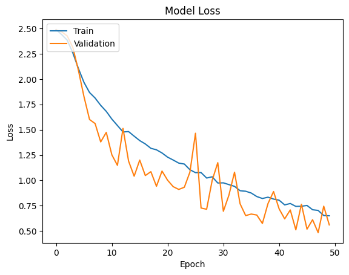

```python
plot_loss(history3)
```

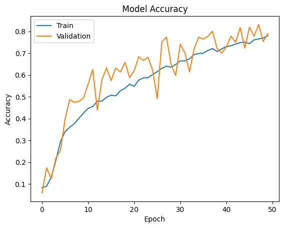

```python
plot_accuracy(history3)
```

```
23/23 ━━━━━━━━━━━━━━━━━━━━ 1s 18ms/step
```

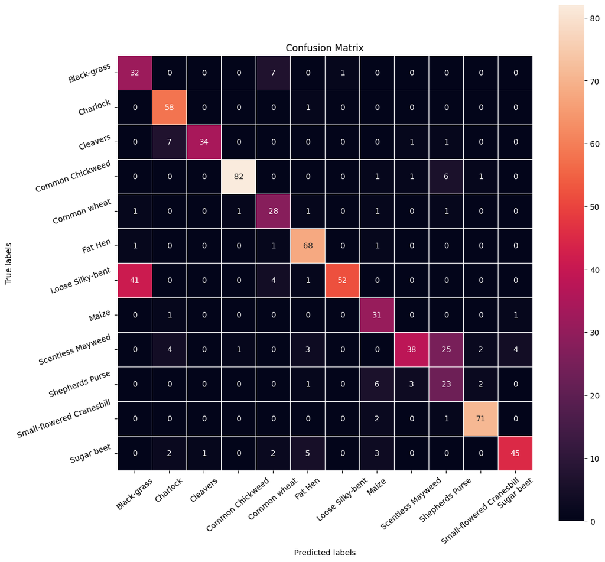

```
              precision    recall  f1-score   support

           0       0.43      0.80      0.56        40
           1       0.81      0.98      0.89        59
           2       0.97      0.79      0.87        43
           3       0.98      0.90      0.94        91
           4       0.67      0.85      0.75        33
           5       0.85      0.96      0.90        71
           6       0.98      0.53      0.69        98
           7       0.69      0.94      0.79        33
           8       0.88      0.49      0.63        77
           9       0.40      0.66      0.50        35
          10       0.93      0.96      0.95        74
          11       0.90      0.78      0.83        58

    accuracy                           0.79       712
   macro avg       0.79      0.80      0.77       712
weighted avg       0.84      0.79      0.79       712
```

```python
plot_confusion_matrix_and_report(model3, x_val_normalized, y_val_encoded)
```

#### **Observations**

**Loss and Accuracy Plots**:

- Training loss steadily decreases, indicating the model is learning effectively from the augmented data. Training accuracy gradually increases, stabilizing around **79%**, which shows good learning without overfitting.
- Validation loss follows a similar decreasing trend, with occasional spikes due to the augmented data variability. Validation accuracy stabilizes around **~79%**, indicating significant improvement over previous models and good generalization.

**Confusion Matrix**:

**Classification Report**:

**Improvements Made:**

1. **Data Augmentation**: The use of `ImageDataGenerator` introduced variability in the training data, leading to better generalization and improved validation accuracy.
2. **Regularization**: Adding **Dropout layers** reduced overfitting and helped improve validation performance.
3. **Complexity**: Adding an extra dense layer and increasing the number of neurons allowed the model to capture more complex patterns.

**Strengths:**

### Fourth Iteration

**Improvement Options**

- Increasing number of epoch to 75 to check if the model trains more on the training dataset.
- Use of `ReduceLROnPlateau` with a factor=0.1, patience=5 and min learning rate up to **1e-6** (0.000001)
- Also intoducing early stopping if loss does not decrease over 10 epochs.

```python
# Creating & Fitting DataGenerator

augmented_datagen = ImageDataGenerator(
    rotation_range=20,
    width_shift_range=0.2,
    height_shift_range=0.2,
    horizontal_flip=True
)
augmented_datagen.fit(x_train_normalized)

# Define ReduceLROnPlateau callback <-- Added New
reduce_lr = ReduceLROnPlateau(
    monitor='val_loss',        # Monitor validation loss
    factor=0.1,                # Reduce learning rate by a factor of 0.1
    patience=5,                # Wait 5 epochs for improvement
    min_lr=1e-6,               # Set a minimum learning rate
    verbose=1                  # Print learning rate changes
)

# Optionally, add EarlyStopping for better monitoring <-- Added New
early_stopping = EarlyStopping(
    monitor='val_loss',
    patience=10,               # Stop training if no improvement for 10 epochs
    restore_best_weights=True  # Restore the best weights from training
)



# Building the fourth model
model4 = Sequential([
    # First Conv2D layer
    Conv2D(filters=32, kernel_size=(3, 3), activation='relu', padding='same', input_shape=(64, 64, 3)),

    # Second Conv2D layer
    Conv2D(filters=64, kernel_size=(3, 3), activation='relu', padding='same'),

    # First MaxPooling layer
    MaxPooling2D(pool_size=(2, 2)),

    # Third Conv2D layer
    Conv2D(filters=64, kernel_size=(3, 3), activation='relu', padding='same'),

    # Fourth Conv2D layer
    Conv2D(filters=128, kernel_size=(3, 3), activation='relu', padding='same'),

    # Second MaxPooling layer
    MaxPooling2D(pool_size=(2, 2)),

    # First Dropout Layer
    Dropout(0.25),


    # BatchNormalization
    BatchNormalization(),

    # Flatten the output
    Flatten(),

    # First Dense layer with 16 neurons
    Dense(16, activation='relu'),

    # Second Dense layer with 32 neurons
    Dense(32, activation='relu'),

    # Second Dropout Layer
    Dropout(0.25),

    # Output layer with 12 neurons for 12 classes
    Dense(12, activation='softmax')
])

# Compile the model
model4.compile(optimizer=Adam(learning_rate=1e-4),# Reduced learning_rate=0.0005
               loss='categorical_crossentropy',
               metrics=['accuracy'])

# Print the model summary
model4.summary()
```

```
Model: "sequential_1"
```

```
┏━━━━━━━━━━━━━━━━━━━━━━━━━━━━━━━━━━━━━━┳━━━━━━━━━━━━━━━━━━━━━━━━━━━━━┳━━━━━━━━━━━━━━━━━┓
┃ Layer (type)                         ┃ Output Shape                ┃         Param # ┃
┡━━━━━━━━━━━━━━━━━━━━━━━━━━━━━━━━━━━━━━╇━━━━━━━━━━━━━━━━━━━━━━━━━━━━━╇━━━━━━━━━━━━━━━━━┩
│ conv2d_4 (Conv2D)                    │ (None, 64, 64, 32)          │             896 │
├──────────────────────────────────────┼─────────────────────────────┼─────────────────┤
│ conv2d_5 (Conv2D)                    │ (None, 64, 64, 64)          │          18,496 │
├──────────────────────────────────────┼─────────────────────────────┼─────────────────┤
│ max_pooling2d_2 (MaxPooling2D)       │ (None, 32, 32, 64)          │               0 │
├──────────────────────────────────────┼─────────────────────────────┼─────────────────┤
│ conv2d_6 (Conv2D)                    │ (None, 32, 32, 64)          │          36,928 │
├──────────────────────────────────────┼─────────────────────────────┼─────────────────┤
│ conv2d_7 (Conv2D)                    │ (None, 32, 32, 128)         │          73,856 │
├──────────────────────────────────────┼─────────────────────────────┼─────────────────┤
│ max_pooling2d_3 (MaxPooling2D)       │ (None, 16, 16, 128)         │               0 │
├──────────────────────────────────────┼─────────────────────────────┼─────────────────┤
│ dropout_2 (Dropout)                  │ (None, 16, 16, 128)         │               0 │
├──────────────────────────────────────┼─────────────────────────────┼─────────────────┤
│ batch_normalization_1                │ (None, 16, 16, 128)         │             512 │
│ (BatchNormalization)                 │                             │                 │
├──────────────────────────────────────┼─────────────────────────────┼─────────────────┤
│ flatten_1 (Flatten)                  │ (None, 32768)               │               0 │
├──────────────────────────────────────┼─────────────────────────────┼─────────────────┤
│ dense_3 (Dense)                      │ (None, 16)                  │         524,304 │
├──────────────────────────────────────┼─────────────────────────────┼─────────────────┤
│ dense_4 (Dense)                      │ (None, 32)                  │             544 │
├──────────────────────────────────────┼─────────────────────────────┼─────────────────┤
│ dropout_3 (Dropout)                  │ (None, 32)                  │               0 │
├──────────────────────────────────────┼─────────────────────────────┼─────────────────┤
│ dense_5 (Dense)                      │ (None, 12)                  │             396 │
└──────────────────────────────────────┴─────────────────────────────┴─────────────────┘
```

```
 Total params: 655,932 (2.50 MB)
```

```
 Trainable params: 655,676 (2.50 MB)
```

```
 Non-trainable params: 256 (1.00 KB)
```

```python
# Resetting the environment default seed=1
reset_environment()

# Fit the model
history4 = model4.fit(
          augmented_datagen.flow( # Data Augmentation
              x_train_normalized,
              y_train_encoded,
              batch_size=32),
          epochs=75, # <-- Added New
          validation_data=(x_val_normalized,
                            y_val_encoded),
          class_weight=class_weights_dict,
          callbacks=[reduce_lr, early_stopping], # <-- Added New
          verbose=2)
```

```
104/104 - 14s - 131ms/step - accuracy: 0.0917 - loss: 2.4606 - val_accuracy: 0.1419 - val_loss: 2.4766 - learning_rate: 1.0000e-04
104/104 - 13s - 127ms/step - accuracy: 0.1678 - loss: 2.2593 - val_accuracy: 0.2037 - val_loss: 2.4191 - learning_rate: 1.0000e-04
104/104 - 5s - 49ms/step - accuracy: 0.2087 - loss: 2.1042 - val_accuracy: 0.2584 - val_loss: 2.3243 - learning_rate: 1.0000e-04
104/104 - 7s - 63ms/step - accuracy: 0.2424 - loss: 2.0196 - val_accuracy: 0.2584 - val_loss: 2.2018 - learning_rate: 1.0000e-04
104/104 - 9s - 89ms/step - accuracy: 0.2824 - loss: 1.9240 - val_accuracy: 0.3455 - val_loss: 1.9642 - learning_rate: 1.0000e-04
104/104 - 5s - 50ms/step - accuracy: 0.3068 - loss: 1.8605 - val_accuracy: 0.3961 - val_loss: 1.7538 - learning_rate: 1.0000e-04
104/104 - 4s - 37ms/step - accuracy: 0.3528 - loss: 1.7715 - val_accuracy: 0.4537 - val_loss: 1.5667 - learning_rate: 1.0000e-04
104/104 - 6s - 58ms/step - accuracy: 0.3456 - loss: 1.7474 - val_accuracy: 0.4270 - val_loss: 1.5738 - learning_rate: 1.0000e-04
104/104 - 5s - 46ms/step - accuracy: 0.3660 - loss: 1.7005 - val_accuracy: 0.4831 - val_loss: 1.4819 - learning_rate: 1.0000e-04
104/104 - 4s - 41ms/step - accuracy: 0.4012 - loss: 1.6588 - val_accuracy: 0.4621 - val_loss: 1.4873 - learning_rate: 1.0000e-04
104/104 - 7s - 64ms/step - accuracy: 0.3979 - loss: 1.6353 - val_accuracy: 0.5211 - val_loss: 1.3143 - learning_rate: 1.0000e-04
104/104 - 9s - 84ms/step - accuracy: 0.4373 - loss: 1.5464 - val_accuracy: 0.5169 - val_loss: 1.3746 - learning_rate: 1.0000e-04
104/104 - 7s - 66ms/step - accuracy: 0.4382 - loss: 1.5432 - val_accuracy: 0.5084 - val_loss: 1.2595 - learning_rate: 1.0000e-04
104/104 - 4s - 38ms/step - accuracy: 0.4547 - loss: 1.4959 - val_accuracy: 0.5941 - val_loss: 1.1640 - learning_rate: 1.0000e-04
104/104 - 4s - 38ms/step - accuracy: 0.4683 - loss: 1.4821 - val_accuracy: 0.5801 - val_loss: 1.1780 - learning_rate: 1.0000e-04
104/104 - 6s - 61ms/step - accuracy: 0.4776 - loss: 1.4364 - val_accuracy: 0.6110 - val_loss: 1.1521 - learning_rate: 1.0000e-04
104/104 - 4s - 38ms/step - accuracy: 0.4974 - loss: 1.3982 - val_accuracy: 0.5520 - val_loss: 1.1993 - learning_rate: 1.0000e-04
104/104 - 6s - 58ms/step - accuracy: 0.4947 - loss: 1.4028 - val_accuracy: 0.4284 - val_loss: 1.5066 - learning_rate: 1.0000e-04
104/104 - 5s - 46ms/step - accuracy: 0.5068 - loss: 1.3732 - val_accuracy: 0.6110 - val_loss: 1.0438 - learning_rate: 1.0000e-04
104/104 - 4s - 41ms/step - accuracy: 0.5038 - loss: 1.3469 - val_accuracy: 0.5857 - val_loss: 1.0751 - learning_rate: 1.0000e-04
104/104 - 5s - 45ms/step - accuracy: 0.5248 - loss: 1.3147 - val_accuracy: 0.6461 - val_loss: 1.0268 - learning_rate: 1.0000e-04
104/104 - 5s - 47ms/step - accuracy: 0.5453 - loss: 1.2753 - val_accuracy: 0.6826 - val_loss: 0.9388 - learning_rate: 1.0000e-04
104/104 - 4s - 37ms/step - accuracy: 0.5420 - loss: 1.2885 - val_accuracy: 0.6194 - val_loss: 1.0192 - learning_rate: 1.0000e-04
104/104 - 4s - 43ms/step - accuracy: 0.5555 - loss: 1.2275 - val_accuracy: 0.5885 - val_loss: 1.1245 - learning_rate: 1.0000e-04
104/104 - 5s - 47ms/step - accuracy: 0.5762 - loss: 1.1709 - val_accuracy: 0.6208 - val_loss: 1.0716 - learning_rate: 1.0000e-04
104/104 - 4s - 39ms/step - accuracy: 0.5886 - loss: 1.1713 - val_accuracy: 0.5323 - val_loss: 1.3115 - learning_rate: 1.0000e-04
104/104 - 7s - 63ms/step - accuracy: 0.5835 - loss: 1.1570 - val_accuracy: 0.6545 - val_loss: 0.9381 - learning_rate: 1.0000e-04
104/104 - 4s - 41ms/step - accuracy: 0.5937 - loss: 1.1330 - val_accuracy: 0.6531 - val_loss: 0.9837 - learning_rate: 1.0000e-04
104/104 - 4s - 38ms/step - accuracy: 0.6018 - loss: 1.1134 - val_accuracy: 0.6784 - val_loss: 0.7970 - learning_rate: 1.0000e-04
104/104 - 5s - 45ms/step - accuracy: 0.6174 - loss: 1.0690 - val_accuracy: 0.5702 - val_loss: 1.2178 - learning_rate: 1.0000e-04
104/104 - 5s - 46ms/step - accuracy: 0.6223 - loss: 1.0510 - val_accuracy: 0.5843 - val_loss: 1.1018 - learning_rate: 1.0000e-04
104/104 - 4s - 37ms/step - accuracy: 0.6268 - loss: 1.0309 - val_accuracy: 0.5871 - val_loss: 1.1697 - learning_rate: 1.0000e-04
104/104 - 7s - 65ms/step - accuracy: 0.6346 - loss: 1.0215 - val_accuracy: 0.7261 - val_loss: 0.7669 - learning_rate: 1.0000e-04
104/104 - 9s - 83ms/step - accuracy: 0.6508 - loss: 0.9679 - val_accuracy: 0.6882 - val_loss: 0.7650 - learning_rate: 1.0000e-04
104/104 - 7s - 64ms/step - accuracy: 0.6547 - loss: 0.9858 - val_accuracy: 0.4803 - val_loss: 1.5556 - learning_rate: 1.0000e-04
104/104 - 4s - 38ms/step - accuracy: 0.6466 - loss: 0.9770 - val_accuracy: 0.7654 - val_loss: 0.6657 - learning_rate: 1.0000e-04
104/104 - 5s - 52ms/step - accuracy: 0.6547 - loss: 0.9424 - val_accuracy: 0.6671 - val_loss: 0.8831 - learning_rate: 1.0000e-04
104/104 - 5s - 50ms/step - accuracy: 0.6776 - loss: 0.8883 - val_accuracy: 0.6685 - val_loss: 0.8156 - learning_rate: 1.0000e-04
104/104 - 10s - 95ms/step - accuracy: 0.6842 - loss: 0.9033 - val_accuracy: 0.7640 - val_loss: 0.6301 - learning_rate: 1.0000e-04
104/104 - 5s - 47ms/step - accuracy: 0.6899 - loss: 0.8876 - val_accuracy: 0.7149 - val_loss: 0.7230 - learning_rate: 1.0000e-04
```

[output cut: 24 more lines]

```
104/104 - 6s - 55ms/step - accuracy: 0.7720 - loss: 0.6472 - val_accuracy: 0.8455 - val_loss: 0.4310 - learning_rate: 1.0000e-05

Epoch 64: ReduceLROnPlateau reducing learning rate to 1e-06.
104/104 - 4s - 42ms/step - accuracy: 0.7723 - loss: 0.6182 - val_accuracy: 0.8385 - val_loss: 0.4274 - learning_rate: 1.0000e-05
104/104 - 5s - 46ms/step - accuracy: 0.7780 - loss: 0.6113 - val_accuracy: 0.8329 - val_loss: 0.4286 - learning_rate: 1.0000e-06
104/104 - 5s - 46ms/step - accuracy: 0.7826 - loss: 0.6115 - val_accuracy: 0.8371 - val_loss: 0.4310 - learning_rate: 1.0000e-06
104/104 - 4s - 41ms/step - accuracy: 0.7768 - loss: 0.6144 - val_accuracy: 0.8441 - val_loss: 0.4272 - learning_rate: 1.0000e-06
104/104 - 7s - 67ms/step - accuracy: 0.7747 - loss: 0.6379 - val_accuracy: 0.8455 - val_loss: 0.4261 - learning_rate: 1.0000e-06
104/104 - 4s - 38ms/step - accuracy: 0.7829 - loss: 0.6120 - val_accuracy: 0.8427 - val_loss: 0.4294 - learning_rate: 1.0000e-06
104/104 - 4s - 38ms/step - accuracy: 0.7814 - loss: 0.5919 - val_accuracy: 0.8399 - val_loss: 0.4290 - learning_rate: 1.0000e-06
104/104 - 7s - 64ms/step - accuracy: 0.7838 - loss: 0.6242 - val_accuracy: 0.8357 - val_loss: 0.4380 - learning_rate: 1.0000e-06
104/104 - 4s - 37ms/step - accuracy: 0.7693 - loss: 0.6260 - val_accuracy: 0.8469 - val_loss: 0.4340 - learning_rate: 1.0000e-06
104/104 - 5s - 49ms/step - accuracy: 0.7826 - loss: 0.6275 - val_accuracy: 0.8413 - val_loss: 0.4287 - learning_rate: 1.0000e-06
104/104 - 6s - 56ms/step - accuracy: 0.7814 - loss: 0.6244 - val_accuracy: 0.8427 - val_loss: 0.4289 - learning_rate: 1.0000e-06
104/104 - 4s - 37ms/step - accuracy: 0.7844 - loss: 0.6103 - val_accuracy: 0.8413 - val_loss: 0.4293 - learning_rate: 1.0000e-06
```

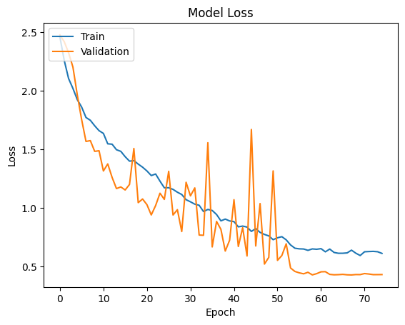

```python
plot_loss(history4)
```

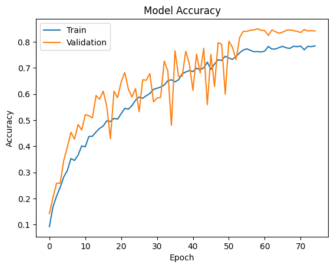

```python
plot_accuracy(history4)
```

```
23/23 ━━━━━━━━━━━━━━━━━━━━ 1s 15ms/step
```

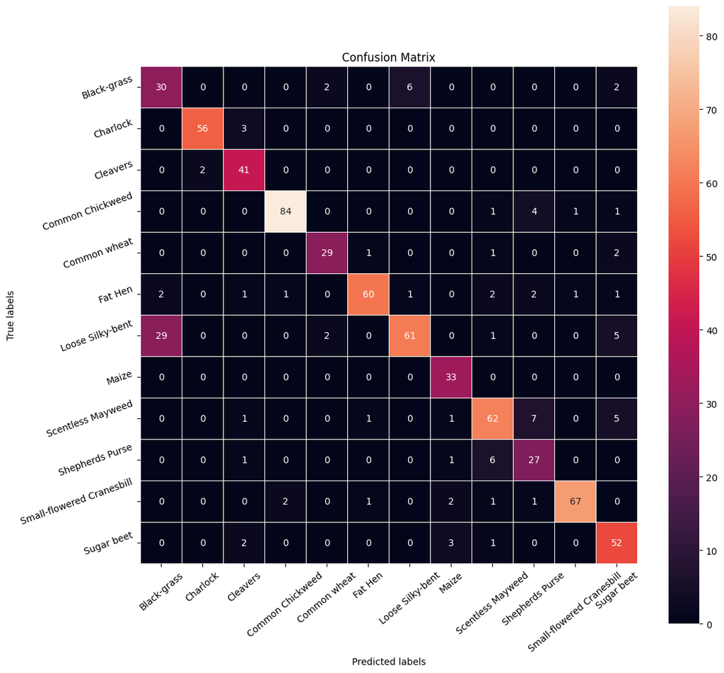

```
              precision    recall  f1-score   support

           0       0.49      0.75      0.59        40
           1       0.97      0.95      0.96        59
           2       0.84      0.95      0.89        43
           3       0.97      0.92      0.94        91
           4       0.88      0.88      0.88        33
           5       0.95      0.85      0.90        71
           6       0.90      0.62      0.73        98
           7       0.82      1.00      0.90        33
           8       0.83      0.81      0.82        77
           9       0.66      0.77      0.71        35
          10       0.97      0.91      0.94        74
          11       0.76      0.90      0.83        58

    accuracy                           0.85       712
   macro avg       0.84      0.86      0.84       712
weighted avg       0.86      0.85      0.85       712
```

```python
plot_confusion_matrix_and_report(model4, x_val_normalized, y_val_encoded)
```

#### **Observations**

**Loss and Accuracy Plots**

- The loss plot shows consistent reduction in training.
- Validation losses over the epochs. There are fluctuations in validation loss due to data augmentation but a general downward trend.
- The accuracy plot indicates that training accuracy has plateaued around 78%. with training accuracy lagging behind validation accuracy.
- Validation accuracy has plateaued around 85%, with training accuracy lagging slightly, suggesting a well-balanced model.

**Confusion Matrix**

- Misclassifications still occur, particularly among visually similar classes such as Loose `Silky-bent` and other similar grasses.
- Some minority classes like `Shepherds Purse` still show limited improvement. Class imbalance a possible reason.

**Classification Report**

- Macro average precision, recall, and F1 score have improved significantly to 84-86%, with the weighted average closely matching.
- Precision and recall are high for some dominant classes (e.g., `Charlock`, `Common Chickweed`, `Cleavers`), but lower for a few minority classes.

**Improvements Made**

1. **Use of `ReduceLROnPlateau`**: Dynamically adjusting the learning rate helped stabilize training, leading to smoother convergence for both training and validation loss function.
2. **Increased Epochs**: Increasing epochs to **75** allowed the model to learn and refine patterns more, resulting improved generalization.
3. **Regularization**: Adding dropout layers reduced overfitting, making validation metrics more similar with training metrics.
4. **Better Data Augmentation**: Augmented data helped robustness and variability, resulting in better generalization to unseen data.

**Strengths**

- **Generalization**: Training and validation loss/accuracy are well-aligned, indicating less overfitting.
- **Class Performance**: Improved precision, recall, and F1-scores across most classes.
- **Stability**: The use of `ReduceLROnPlateau` ensured stable convergence, with the model responding well to learning rate adjustments.

### Fifth Iteration - Using Transfer Learning

**Improvement Criteria**

- Using pre-trained model - `tensorflow.keras.applications.VGG16`
- This model can accept our reduced image size (64 X 64 X 3).
- Early stopping paitence increased to 20 from 10.

```python
# The VGG16 model with 64 X 64 X 3 input size
base_model = VGG16(weights='imagenet', include_top=False, input_shape=(64, 64, 3))
base_model.summary()
```

```
Model: "vgg16"
```

```
┏━━━━━━━━━━━━━━━━━━━━━━━━━━━━━━━━━━━━━━┳━━━━━━━━━━━━━━━━━━━━━━━━━━━━━┳━━━━━━━━━━━━━━━━━┓
┃ Layer (type)                         ┃ Output Shape                ┃         Param # ┃
┡━━━━━━━━━━━━━━━━━━━━━━━━━━━━━━━━━━━━━━╇━━━━━━━━━━━━━━━━━━━━━━━━━━━━━╇━━━━━━━━━━━━━━━━━┩
│ input_layer_7 (InputLayer)           │ (None, 64, 64, 3)           │               0 │
├──────────────────────────────────────┼─────────────────────────────┼─────────────────┤
│ block1_conv1 (Conv2D)                │ (None, 64, 64, 64)          │           1,792 │
├──────────────────────────────────────┼─────────────────────────────┼─────────────────┤
│ block1_conv2 (Conv2D)                │ (None, 64, 64, 64)          │          36,928 │
├──────────────────────────────────────┼─────────────────────────────┼─────────────────┤
│ block1_pool (MaxPooling2D)           │ (None, 32, 32, 64)          │               0 │
├──────────────────────────────────────┼─────────────────────────────┼─────────────────┤
│ block2_conv1 (Conv2D)                │ (None, 32, 32, 128)         │          73,856 │
├──────────────────────────────────────┼─────────────────────────────┼─────────────────┤
│ block2_conv2 (Conv2D)                │ (None, 32, 32, 128)         │         147,584 │
├──────────────────────────────────────┼─────────────────────────────┼─────────────────┤
│ block2_pool (MaxPooling2D)           │ (None, 16, 16, 128)         │               0 │
├──────────────────────────────────────┼─────────────────────────────┼─────────────────┤
│ block3_conv1 (Conv2D)                │ (None, 16, 16, 256)         │         295,168 │
├──────────────────────────────────────┼─────────────────────────────┼─────────────────┤
│ block3_conv2 (Conv2D)                │ (None, 16, 16, 256)         │         590,080 │
├──────────────────────────────────────┼─────────────────────────────┼─────────────────┤
│ block3_conv3 (Conv2D)                │ (None, 16, 16, 256)         │         590,080 │
├──────────────────────────────────────┼─────────────────────────────┼─────────────────┤
│ block3_pool (MaxPooling2D)           │ (None, 8, 8, 256)           │               0 │
├──────────────────────────────────────┼─────────────────────────────┼─────────────────┤
│ block4_conv1 (Conv2D)                │ (None, 8, 8, 512)           │       1,180,160 │
├──────────────────────────────────────┼─────────────────────────────┼─────────────────┤
│ block4_conv2 (Conv2D)                │ (None, 8, 8, 512)           │       2,359,808 │
├──────────────────────────────────────┼─────────────────────────────┼─────────────────┤
│ block4_conv3 (Conv2D)                │ (None, 8, 8, 512)           │       2,359,808 │
├──────────────────────────────────────┼─────────────────────────────┼─────────────────┤
│ block4_pool (MaxPooling2D)           │ (None, 4, 4, 512)           │               0 │
├──────────────────────────────────────┼─────────────────────────────┼─────────────────┤
│ block5_conv1 (Conv2D)                │ (None, 4, 4, 512)           │       2,359,808 │
├──────────────────────────────────────┼─────────────────────────────┼─────────────────┤
│ block5_conv2 (Conv2D)                │ (None, 4, 4, 512)           │       2,359,808 │
├──────────────────────────────────────┼─────────────────────────────┼─────────────────┤
│ block5_conv3 (Conv2D)                │ (None, 4, 4, 512)           │       2,359,808 │
├──────────────────────────────────────┼─────────────────────────────┼─────────────────┤
│ block5_pool (MaxPooling2D)           │ (None, 2, 2, 512)           │               0 │
└──────────────────────────────────────┴─────────────────────────────┴─────────────────┘
```

```
 Total params: 14,714,688 (56.13 MB)
```

```
 Trainable params: 14,714,688 (56.13 MB)
```

```
 Non-trainable params: 0 (0.00 B)
```

```python
# Getting only the conv layers for transfer learning.
transfer_layer = base_model.get_layer('block5_pool')
vgg_base_model = Model(inputs=base_model.input, outputs=transfer_layer.output)


# Freeze the base model layers to prevent training
for layer in vgg_base_model.layers:
    layer.trainable = False

for layer in vgg_base_model.layers:
    print(layer.name, layer.trainable)

# Define ReduceLROnPlateau callback
reduce_lr = ReduceLROnPlateau(
    monitor='val_loss',        # Monitor validation loss
    factor=0.1,                # Reduce learning rate by a factor of 0.1
    patience=5,                # Wait 5 epochs for improvement
    min_lr=1e-6,               # Set a minimum learning rate
    verbose=1                  # Print learning rate changes
)

# Optionally, add EarlyStopping for better monitoring
early_stopping = EarlyStopping(
    monitor='val_loss',
    patience=20,               # Stop training if no improvement for 10 epochs
    restore_best_weights=True  # Restore the best weights from training
)

# Add custom layers on top
transfer_model = Sequential([
    vgg_base_model,                          # Pre-trained VGG base model
    Flatten(),
    Dense(128, activation='relu'),           # Fully connected layer
    Dropout(0.25),                           # Dropout for regularization
    Dense(64, activation='relu'),            # Another dense layer
    Dropout(0.25),                           # Another dropout
    Dense(12, activation='softmax')          # Output layer for 12 classes
])

# Compile the model
transfer_model.compile(
    optimizer=Adam(learning_rate=1e-4),      # Learning rate for transfer learning
    loss='categorical_crossentropy',
    metrics=['accuracy']
)

# Print model summary
transfer_model.summary()
```

```
input_layer_7 False
block1_conv1 False
block1_conv2 False
block1_pool False
block2_conv1 False
block2_conv2 False
block2_pool False
block3_conv1 False
block3_conv2 False
block3_conv3 False
block3_pool False
block4_conv1 False
block4_conv2 False
block4_conv3 False
block4_pool False
block5_conv1 False
block5_conv2 False
block5_conv3 False
block5_pool False
```

```
Model: "sequential_3"
```

```
┏━━━━━━━━━━━━━━━━━━━━━━━━━━━━━━━━━━━━━━┳━━━━━━━━━━━━━━━━━━━━━━━━━━━━━┳━━━━━━━━━━━━━━━━━┓
┃ Layer (type)                         ┃ Output Shape                ┃         Param # ┃
┡━━━━━━━━━━━━━━━━━━━━━━━━━━━━━━━━━━━━━━╇━━━━━━━━━━━━━━━━━━━━━━━━━━━━━╇━━━━━━━━━━━━━━━━━┩
│ functional_6 (Functional)            │ (None, 2, 2, 512)           │      14,714,688 │
├──────────────────────────────────────┼─────────────────────────────┼─────────────────┤
│ flatten_3 (Flatten)                  │ (None, 2048)                │               0 │
├──────────────────────────────────────┼─────────────────────────────┼─────────────────┤
│ dense_9 (Dense)                      │ (None, 128)                 │         262,272 │
├──────────────────────────────────────┼─────────────────────────────┼─────────────────┤
│ dropout_6 (Dropout)                  │ (None, 128)                 │               0 │
├──────────────────────────────────────┼─────────────────────────────┼─────────────────┤
│ dense_10 (Dense)                     │ (None, 64)                  │           8,256 │
├──────────────────────────────────────┼─────────────────────────────┼─────────────────┤
│ dropout_7 (Dropout)                  │ (None, 64)                  │               0 │
├──────────────────────────────────────┼─────────────────────────────┼─────────────────┤
│ dense_11 (Dense)                     │ (None, 12)                  │             780 │
└──────────────────────────────────────┴─────────────────────────────┴─────────────────┘
```

```
 Total params: 14,985,996 (57.17 MB)
```

```
 Trainable params: 271,308 (1.03 MB)
```

```
 Non-trainable params: 14,714,688 (56.13 MB)
```

```python
# Resetting the environment default seed=1
reset_environment()

# Train the transfer learning model
history_transfer = transfer_model.fit(
    augmented_datagen.flow(
        x_train_normalized,
        y_train_encoded,
        batch_size=32
    ),
    validation_data=(x_val_normalized, y_val_encoded),
    epochs=75,
    callbacks=[reduce_lr, early_stopping],
    class_weight=class_weights_dict,
    verbose=2
)
```

```
104/104 - 12s - 117ms/step - accuracy: 0.1158 - loss: 2.4987 - val_accuracy: 0.1798 - val_loss: 2.3882 - learning_rate: 1.0000e-04
104/104 - 5s - 49ms/step - accuracy: 0.1555 - loss: 2.3911 - val_accuracy: 0.2542 - val_loss: 2.2776 - learning_rate: 1.0000e-04
104/104 - 9s - 90ms/step - accuracy: 0.1973 - loss: 2.3091 - val_accuracy: 0.2669 - val_loss: 2.1859 - learning_rate: 1.0000e-04
104/104 - 6s - 56ms/step - accuracy: 0.2162 - loss: 2.2269 - val_accuracy: 0.3118 - val_loss: 2.1070 - learning_rate: 1.0000e-04
104/104 - 4s - 40ms/step - accuracy: 0.2478 - loss: 2.1669 - val_accuracy: 0.3413 - val_loss: 2.0284 - learning_rate: 1.0000e-04
104/104 - 5s - 49ms/step - accuracy: 0.2406 - loss: 2.1274 - val_accuracy: 0.3399 - val_loss: 1.9810 - learning_rate: 1.0000e-04
104/104 - 6s - 60ms/step - accuracy: 0.2638 - loss: 2.0496 - val_accuracy: 0.3975 - val_loss: 1.8712 - learning_rate: 1.0000e-04
104/104 - 5s - 44ms/step - accuracy: 0.2950 - loss: 2.0157 - val_accuracy: 0.3666 - val_loss: 1.8441 - learning_rate: 1.0000e-04
104/104 - 7s - 63ms/step - accuracy: 0.2878 - loss: 1.9764 - val_accuracy: 0.3975 - val_loss: 1.8001 - learning_rate: 1.0000e-04
104/104 - 4s - 40ms/step - accuracy: 0.3095 - loss: 1.9463 - val_accuracy: 0.4157 - val_loss: 1.7545 - learning_rate: 1.0000e-04
104/104 - 4s - 39ms/step - accuracy: 0.3284 - loss: 1.8969 - val_accuracy: 0.4031 - val_loss: 1.7337 - learning_rate: 1.0000e-04
104/104 - 7s - 67ms/step - accuracy: 0.3206 - loss: 1.8967 - val_accuracy: 0.4452 - val_loss: 1.6995 - learning_rate: 1.0000e-04
104/104 - 8s - 82ms/step - accuracy: 0.3269 - loss: 1.8562 - val_accuracy: 0.4551 - val_loss: 1.6407 - learning_rate: 1.0000e-04
104/104 - 6s - 56ms/step - accuracy: 0.3408 - loss: 1.8594 - val_accuracy: 0.4494 - val_loss: 1.6358 - learning_rate: 1.0000e-04
104/104 - 4s - 40ms/step - accuracy: 0.3498 - loss: 1.8173 - val_accuracy: 0.4649 - val_loss: 1.6140 - learning_rate: 1.0000e-04
104/104 - 5s - 51ms/step - accuracy: 0.3573 - loss: 1.7997 - val_accuracy: 0.4635 - val_loss: 1.6053 - learning_rate: 1.0000e-04
104/104 - 6s - 54ms/step - accuracy: 0.3609 - loss: 1.7597 - val_accuracy: 0.4775 - val_loss: 1.5519 - learning_rate: 1.0000e-04
104/104 - 4s - 43ms/step - accuracy: 0.3627 - loss: 1.7649 - val_accuracy: 0.4831 - val_loss: 1.5399 - learning_rate: 1.0000e-04
104/104 - 6s - 56ms/step - accuracy: 0.3693 - loss: 1.7438 - val_accuracy: 0.4958 - val_loss: 1.5258 - learning_rate: 1.0000e-04
104/104 - 5s - 46ms/step - accuracy: 0.3844 - loss: 1.7119 - val_accuracy: 0.5014 - val_loss: 1.5010 - learning_rate: 1.0000e-04
104/104 - 4s - 40ms/step - accuracy: 0.3826 - loss: 1.7092 - val_accuracy: 0.5056 - val_loss: 1.4931 - learning_rate: 1.0000e-04
104/104 - 7s - 68ms/step - accuracy: 0.3838 - loss: 1.6856 - val_accuracy: 0.4888 - val_loss: 1.4709 - learning_rate: 1.0000e-04
104/104 - 4s - 40ms/step - accuracy: 0.3877 - loss: 1.6796 - val_accuracy: 0.5169 - val_loss: 1.4594 - learning_rate: 1.0000e-04
104/104 - 5s - 49ms/step - accuracy: 0.3931 - loss: 1.6685 - val_accuracy: 0.5070 - val_loss: 1.4655 - learning_rate: 1.0000e-04
104/104 - 7s - 63ms/step - accuracy: 0.4048 - loss: 1.6482 - val_accuracy: 0.5478 - val_loss: 1.4161 - learning_rate: 1.0000e-04
104/104 - 9s - 91ms/step - accuracy: 0.4183 - loss: 1.6279 - val_accuracy: 0.5197 - val_loss: 1.4174 - learning_rate: 1.0000e-04
104/104 - 5s - 50ms/step - accuracy: 0.4208 - loss: 1.6107 - val_accuracy: 0.5056 - val_loss: 1.4268 - learning_rate: 1.0000e-04
104/104 - 11s - 105ms/step - accuracy: 0.4144 - loss: 1.6096 - val_accuracy: 0.5197 - val_loss: 1.4056 - learning_rate: 1.0000e-04
104/104 - 9s - 83ms/step - accuracy: 0.4226 - loss: 1.5920 - val_accuracy: 0.5309 - val_loss: 1.3774 - learning_rate: 1.0000e-04
104/104 - 7s - 69ms/step - accuracy: 0.4250 - loss: 1.5726 - val_accuracy: 0.5421 - val_loss: 1.3825 - learning_rate: 1.0000e-04
104/104 - 8s - 78ms/step - accuracy: 0.4147 - loss: 1.5713 - val_accuracy: 0.5112 - val_loss: 1.3635 - learning_rate: 1.0000e-04
104/104 - 6s - 56ms/step - accuracy: 0.4352 - loss: 1.5608 - val_accuracy: 0.5309 - val_loss: 1.3568 - learning_rate: 1.0000e-04
104/104 - 9s - 83ms/step - accuracy: 0.4403 - loss: 1.5352 - val_accuracy: 0.5211 - val_loss: 1.3660 - learning_rate: 1.0000e-04
104/104 - 6s - 56ms/step - accuracy: 0.4316 - loss: 1.5437 - val_accuracy: 0.5435 - val_loss: 1.3548 - learning_rate: 1.0000e-04
104/104 - 9s - 83ms/step - accuracy: 0.4337 - loss: 1.5409 - val_accuracy: 0.5225 - val_loss: 1.3677 - learning_rate: 1.0000e-04
104/104 - 6s - 56ms/step - accuracy: 0.4454 - loss: 1.5211 - val_accuracy: 0.5309 - val_loss: 1.3231 - learning_rate: 1.0000e-04
104/104 - 4s - 40ms/step - accuracy: 0.4418 - loss: 1.5244 - val_accuracy: 0.5365 - val_loss: 1.3325 - learning_rate: 1.0000e-04
104/104 - 5s - 46ms/step - accuracy: 0.4490 - loss: 1.4975 - val_accuracy: 0.5604 - val_loss: 1.3006 - learning_rate: 1.0000e-04
104/104 - 5s - 51ms/step - accuracy: 0.4611 - loss: 1.4805 - val_accuracy: 0.5365 - val_loss: 1.3030 - learning_rate: 1.0000e-04
104/104 - 4s - 41ms/step - accuracy: 0.4671 - loss: 1.4825 - val_accuracy: 0.5351 - val_loss: 1.3010 - learning_rate: 1.0000e-04
```

[output cut: 24 more lines]

```
104/104 - 9s - 84ms/step - accuracy: 0.5083 - loss: 1.3367 - val_accuracy: 0.5660 - val_loss: 1.1882 - learning_rate: 1.0000e-04
104/104 - 6s - 55ms/step - accuracy: 0.5035 - loss: 1.3278 - val_accuracy: 0.5772 - val_loss: 1.1780 - learning_rate: 1.0000e-04
104/104 - 9s - 88ms/step - accuracy: 0.5098 - loss: 1.3332 - val_accuracy: 0.5772 - val_loss: 1.1861 - learning_rate: 1.0000e-04

Epoch 68: ReduceLROnPlateau reducing learning rate to 9.999999747378752e-06.
104/104 - 6s - 54ms/step - accuracy: 0.5140 - loss: 1.3124 - val_accuracy: 0.5829 - val_loss: 1.1645 - learning_rate: 1.0000e-04
104/104 - 4s - 40ms/step - accuracy: 0.5278 - loss: 1.3108 - val_accuracy: 0.5871 - val_loss: 1.1592 - learning_rate: 1.0000e-05
104/104 - 7s - 63ms/step - accuracy: 0.5269 - loss: 1.2925 - val_accuracy: 0.5927 - val_loss: 1.1600 - learning_rate: 1.0000e-05
104/104 - 9s - 85ms/step - accuracy: 0.5236 - loss: 1.3082 - val_accuracy: 0.5885 - val_loss: 1.1646 - learning_rate: 1.0000e-05
104/104 - 7s - 66ms/step - accuracy: 0.5137 - loss: 1.2952 - val_accuracy: 0.5871 - val_loss: 1.1623 - learning_rate: 1.0000e-05
104/104 - 8s - 81ms/step - accuracy: 0.5266 - loss: 1.2897 - val_accuracy: 0.5885 - val_loss: 1.1640 - learning_rate: 1.0000e-05

Epoch 74: ReduceLROnPlateau reducing learning rate to 1e-06.
104/104 - 6s - 58ms/step - accuracy: 0.5215 - loss: 1.3048 - val_accuracy: 0.5885 - val_loss: 1.1649 - learning_rate: 1.0000e-05
104/104 - 4s - 39ms/step - accuracy: 0.5272 - loss: 1.2770 - val_accuracy: 0.5899 - val_loss: 1.1640 - learning_rate: 1.0000e-06
```

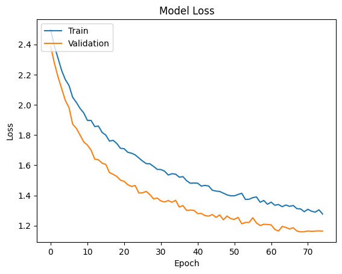

```python
plot_loss(history_transfer)
```

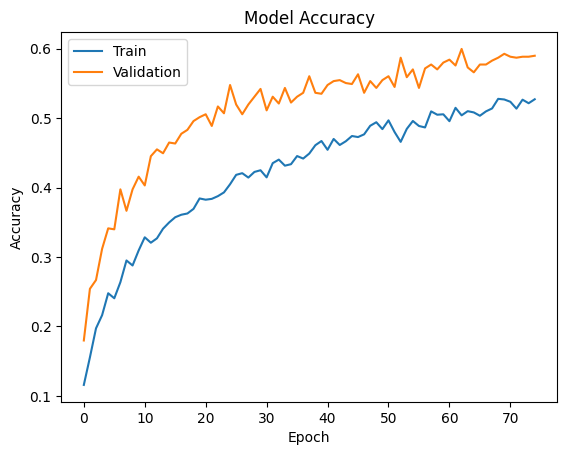

```python
plot_accuracy(history_transfer)
```

**Observations** & **Improvements**

```
23/23 ━━━━━━━━━━━━━━━━━━━━ 1s 32ms/step
```

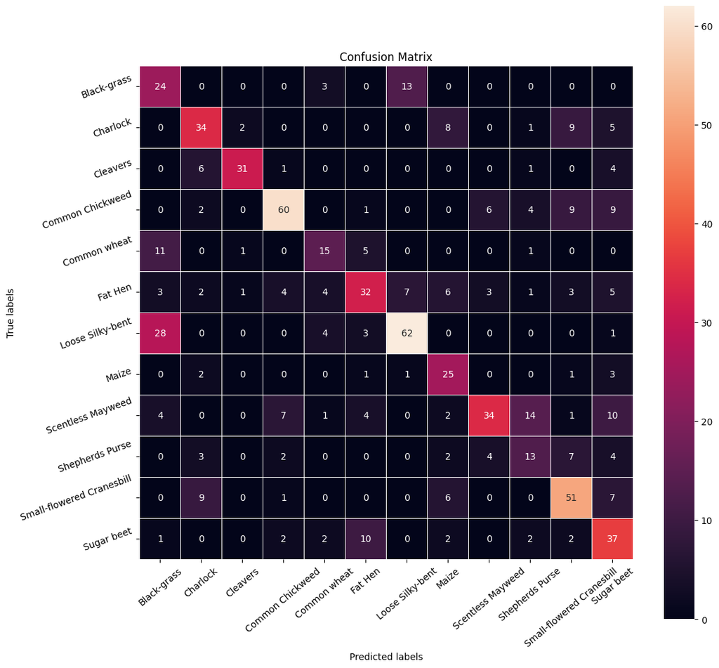

```
              precision    recall  f1-score   support

           0       0.34      0.60      0.43        40
           1       0.59      0.58      0.58        59
           2       0.89      0.72      0.79        43
           3       0.78      0.66      0.71        91
           4       0.52      0.45      0.48        33
           5       0.57      0.45      0.50        71
           6       0.75      0.63      0.69        98
           7       0.49      0.76      0.60        33
           8       0.72      0.44      0.55        77
           9       0.35      0.37      0.36        35
          10       0.61      0.69      0.65        74
          11       0.44      0.64      0.52        58

    accuracy                           0.59       712
   macro avg       0.59      0.58      0.57       712
weighted avg       0.62      0.59      0.59       712
```

```python
plot_confusion_matrix_and_report(transfer_model, x_val_normalized, y_val_encoded)
```

#### **Observations**

**Loss and Accuracy Plots**

- The model shows gradual improvement in training accuracy.
- The validation accuracy converges around 59%.
- Both training and validation loss are decreasing, which indicates proper learning without significant overfitting.

**Confusion Matrix**:

- The model struggles in certain classes (e.g., `Loose Silky-bent` and `Shepherd's Purse`), with low recall and precision in some underrepresented categories.
- Overall Accuracy 59% indicates the model is not fully leveraging the power of the VGG16 base model.

**Classification Report**

- Macro average precision, recall, and F1 score is not close to previous two models.
- Precision and recall are also not as high as previous model but moderately OK.

**All this suggests that the model might not be adequately trained or lacks capacity for this dataset.**

### Comparison Between **Model4** (Custom CNN) and **Transfer_Model** (VGG16 Transfer Learning)

#### **Key Takeaway**

- **Model4** is better suited for this specific dataset, offering higher accuracy and better generalization with lower computational cost.
- **Transfer_Model** underperforms in its current setup, but fine-tuning, higher input resolution, or using a different pre-trained model may improve its performance.

## Final Model

### Brief Comparison of All 5 Models:

1. **Model1 (Base CNN)**:
   - **Performance**: Poor generalization with accuracy around 38%; struggled to extract meaningful features.
2. **Model2 (Enhanced CNN)**:
   - **Improvement**: Added BatchNormalization and additional Conv2D layers; achieved better accuracy (~70%) but still limited in learning complexity.
3. **Model3 (Data Augmentation)**:
   - **Impact**: Data augmentation and Dropout improved generalization; reached ~79% accuracy, indicating robustness to overfitting.
4. **Model4 (Optimized CNN)**:
   - **Best Performer**: Further tuning with ReduceLROnPlateau and EarlyStopping resulted in ~85% accuracy, balancing generalization and learning.
5. **Transfer_Model (VGG16)**:
   - **Underperformed**: Achieved ~59% accuracy; limited by frozen layers and smaller input size, highlighting the need for fine-tuning for better results.

### Final Model Selection

I would choose **Model4 (Optimized Custom CNN)** as the final model because:

- **Highest Accuracy**: It achieved an overall accuracy of **85%**, outperforming all other models in both generalization and learning ability.
- **Balanced Performance**: The combination of BatchNormalization, Dropout, ReduceLROnPlateau, and EarlyStopping effectively prevented overfitting while optimizing training.
- **Scalability**: The architecture can be scaled or further tuned (e.g., by increasing input size or adding more layers) if needed, providing flexibility for future improvements.

Thus, **Model4** provides the best trade-off between accuracy, computational efficiency, and adaptability for this specific task.

### Performance of Final model **(Model-4)** on test data

```
23/23 ━━━━━━━━━━━━━━━━━━━━ 1s 40ms/step
```

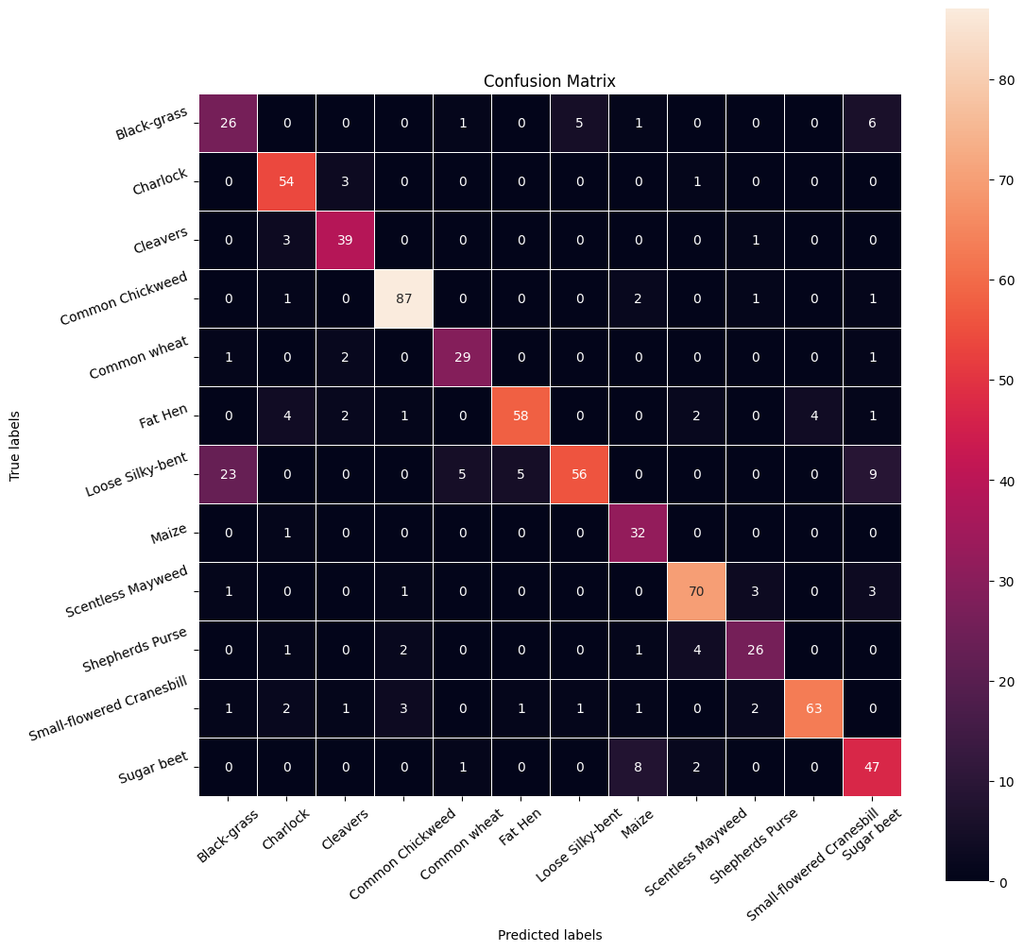

```
              precision    recall  f1-score   support

           0       0.50      0.67      0.57        39
           1       0.82      0.93      0.87        58
           2       0.83      0.91      0.87        43
           3       0.93      0.95      0.94        92
           4       0.81      0.88      0.84        33
           5       0.91      0.81      0.85        72
           6       0.90      0.57      0.70        98
           7       0.71      0.97      0.82        33
           8       0.89      0.90      0.89        78
           9       0.79      0.76      0.78        34
          10       0.94      0.84      0.89        75
          11       0.69      0.81      0.75        58

    accuracy                           0.82       713
   macro avg       0.81      0.83      0.81       713
weighted avg       0.84      0.82      0.82       713
```

```python
plot_confusion_matrix_and_report(model4, x_test_normalized, y_test_encoded)
```

#### Observations:

**Multiclass Classification Confusion Matrix**

- The matrix shows relatively fewer misclassifications, with most predictions concentrated along the diagonal.
- Most classes, such as `Cleavers`, `Common Chickweed`, and `Fat Hen`, exhibit strong performance with F1-scores above 80%.
- Some classes, such as `Loose Silky-bent` and `Shepherd's Purse`, have misclassifications which indicates room for improvement in handling these categories.

**PerformanceMetrics**

- The model achieves an accuracy of **82%**, indicating it can correctly classify the majority of test samples.
- **Macro Precision**: **81%**, reflecting balanced precision across all classes.
- **Macro Recall**: **83%**, showing good recall for minority classes as well.
- **Macro F1-Score**: **81%**, highlighting consistent performance across all metrics.

**Conclusion:** The final model demonstrates strong generalization and consistent performance on the test dataset, validating its suitability for practical use.

### Visualizing the prediction

```python
# Visualizing the predicted and correct label of images from test data
def classify_image(index):
  plt.figure(figsize=(2,2))
  plt.imshow(x_test[index])
  plt.show()
  ## Complete the code to predict the test data using the final model selected
  print('Predicted Label', label_binarizer.inverse_transform(model4.predict((x_test_normalized[index].reshape(1,64,64,3)))))
  print('True Label', label_binarizer.inverse_transform(y_test_encoded)[index])
```

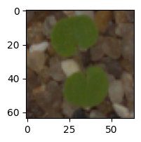

```
1/1 ━━━━━━━━━━━━━━━━━━━━ 0s 17ms/step
Predicted Label ['Small-flowered Cranesbill']
True Label Small-flowered Cranesbill
```

```python
classify_image(2)
```

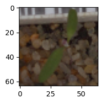

```
1/1 ━━━━━━━━━━━━━━━━━━━━ 0s 17ms/step
Predicted Label ['Fat Hen']
True Label Fat Hen
```

```python
classify_image(4)
```

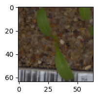

```
1/1 ━━━━━━━━━━━━━━━━━━━━ 0s 20ms/step
Predicted Label ['Sugar beet']
True Label Sugar beet
```

```python
classify_image(10)
```

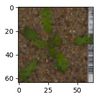

```
1/1 ━━━━━━━━━━━━━━━━━━━━ 0s 17ms/step
Predicted Label ['Maize']
True Label Shepherds Purse
```

```python
classify_image(15)
```

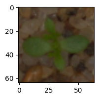

```
1/1 ━━━━━━━━━━━━━━━━━━━━ 0s 18ms/step
Predicted Label ['Scentless Mayweed']
True Label Scentless Mayweed
```

```python
classify_image(23)
```

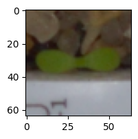

```
1/1 ━━━━━━━━━━━━━━━━━━━━ 0s 29ms/step
Predicted Label ['Common Chickweed']
True Label Scentless Mayweed
```

```python
classify_image(1)
```

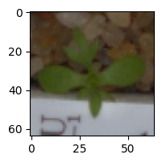

```
1/1 ━━━━━━━━━━━━━━━━━━━━ 0s 18ms/step
Predicted Label ['Scentless Mayweed']
True Label Scentless Mayweed
```

```python
classify_image(61)
```

## Actionable Insights and Business Recommendations

### **Actionable Insights:**

1. **High-performing Classes**: The model performs well on certain categories like `Common Chickweed`, `Cleavers`, and `Fat Hen`, with F1-scores above 80%. These can be trusted for reliable automation in classifying these plant species.
2. **Underperforming Classes**: Classes such as `Loose Silky-bent` and `Shepherd's Purse` show lower recall and precision, potential overlap in visual features or lack of sufficient training observations. Collecting more diverse samples for these classes may improve performance.
3. **Generalization and Robustness on Test Data**: With an overall accuracy of **82%** and balanced class-wise metrics, the model demonstrates good generalization.

### **Business Recommendations:**

1. **Deploy the Model for Automation**: Leverage the model to automate the classification of plant seedlings, reducing manual labor costs and improving efficiency in agricultural operations. Focus on high-performing categories to build initial confidence in the system.
2. **Improve Data for Specific Classes**: Collect more high-quality labeled data for underperforming classes like `Loose Silky-bent` and `Shepherd's Purse`.
3. **Monitor and Enhance Over Time**: A feedback loop where user corrections on misclassifications are incorporated will be benificial. It will ensures continuous improvement and adaptability to new data.
4. **Explore Scalability Using Higher Resolution Images**: Evaluate the model's scalability to larger image sizes if necessary for even finer-grained classification.